# Airline online performance analytics

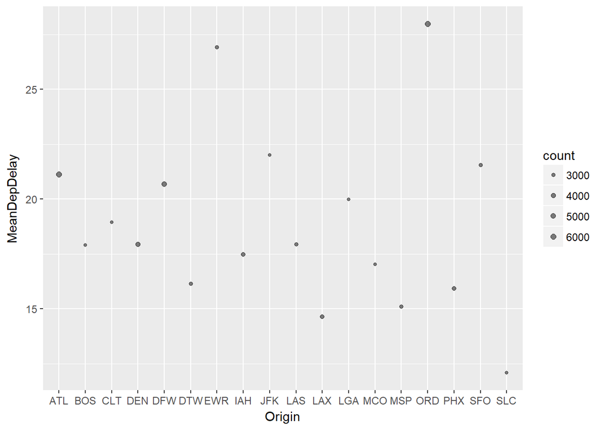

```r
ggplot(OriginAirportDelay, aes(Origin, MeanDepDelay)) + geom_point(aes(size=count), alpha=1/2) + geom_smooth() + scale_size_area(max_size = 2)
```

```r
str(tripsplaneairports)
```

```
## Classes 'data.table' and 'data.frame':   119117 obs. of  46 variables:
##  $ Dest             : Factor w/ 303 levels "ABE","ABI","ABQ",..: 1 1 1 1 1 1 1 1 1 1 ...
##  $ Origin           : Factor w/ 301 levels "ABE","ABI","ABQ",..: 19 19 19 19 19 19 19 19 19 19 ...
##  $ TailNum          : Factor w/ 5603 levels "0","80009E","80019E",..: 4772 4783 4838 4850 4865 4867 4898 5137 5178 5275 ...
##  $ Year             : int  2007 2007 2007 2007 2007 2007 2007 2007 2007 2007 ...
##  $ Month            : int  6 9 6 3 4 7 6 4 2 11 ...
##  $ DayofMonth       : int  3 12 23 25 11 23 5 10 23 25 ...
##  $ DayOfWeek        : int  7 3 6 7 3 1 2 2 5 7 ...
##  $ DepTime          : int  948 1610 955 933 1520 1528 1507 1951 1507 939 ...
##  $ CRSDepTime       : int  948 1450 944 937 1506 1530 1505 1952 1507 939 ...
##  $ ArrTime          : int  1146 1819 1152 1132 1720 1740 1722 2136 1704 1138 ...
##  $ CRSArrTime       : int  1155 1650 1152 1147 1705 1734 1704 2157 1703 1137 ...
##  $ UniqueCarrier    : chr  "EV" "EV" "EV" "EV" ...
##  $ FlightNum        : int  4675 4795 4376 4675 4293 4795 4293 4870 4293 4502 ...
##  $ ActualElapsedTime: int  118 129 117 119 120 132 135 105 117 119 ...
```

[output cut: 34 more lines]

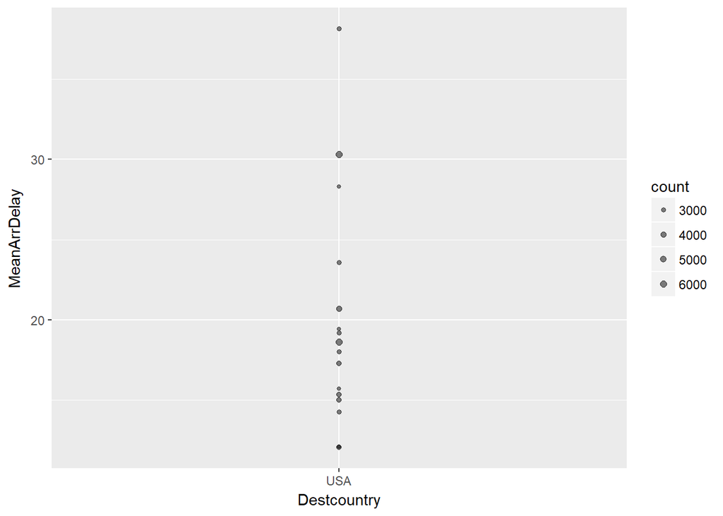

```r
DestAirportDelay <- tripsplaneairports %>%
  group_by(Dest, Destcity, Deststate, Destcountry) %>%
  summarise(count=n(), MeanArrDelay = mean(ArrDelay), MeanDepDelay=mean(DepDelay), MeanWeatherDelay2=mean(WeatherDelay)) %>%
  filter ( count > 2000, !is.na(MeanArrDelay), !is.na(MeanDepDelay) ) %>%
  collect
# Here increased the count, to study cities/states where major no of trips occoured.

ggplot(DestAirportDelay, aes(Destcountry, MeanArrDelay)) + geom_point(aes(size=count), alpha=1/2) + geom_smooth() + scale_size_area(max_size = 2)
```

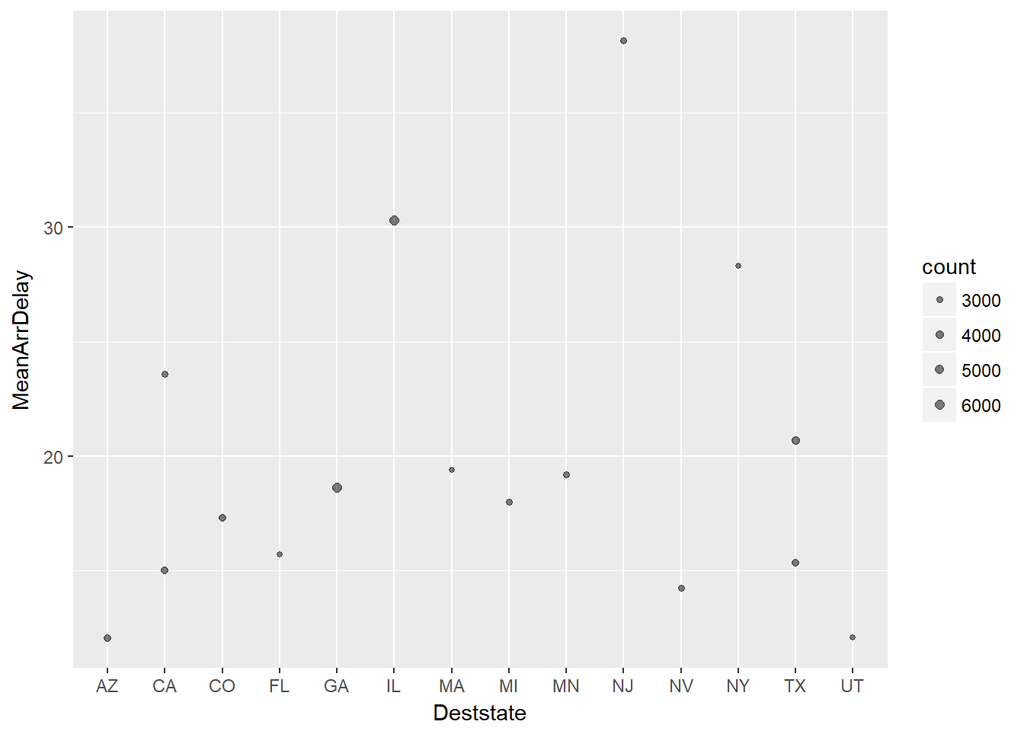

```r
ggplot(DestAirportDelay, aes(Deststate, MeanArrDelay)) + geom_point(aes(size=count), alpha=1/2) + geom_smooth() + scale_size_area(max_size = 2)
```

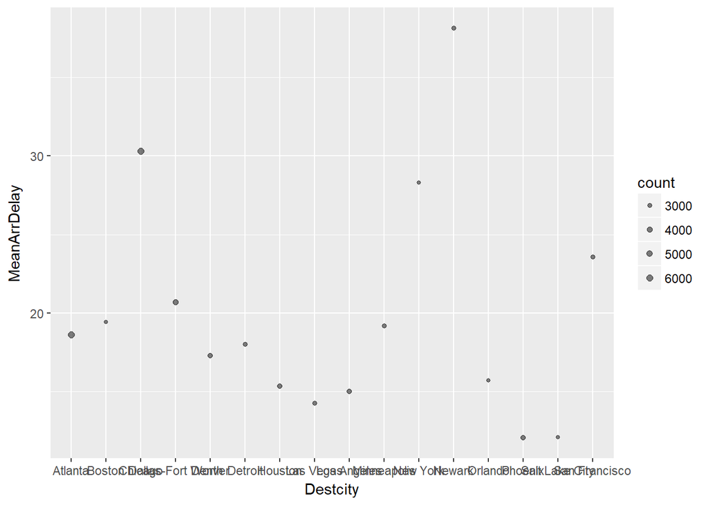

```r
ggplot(DestAirportDelay, aes(Destcity, MeanArrDelay)) + geom_point(aes(size=count), alpha=1/2) + geom_smooth() + scale_size_area(max_size = 2)
```

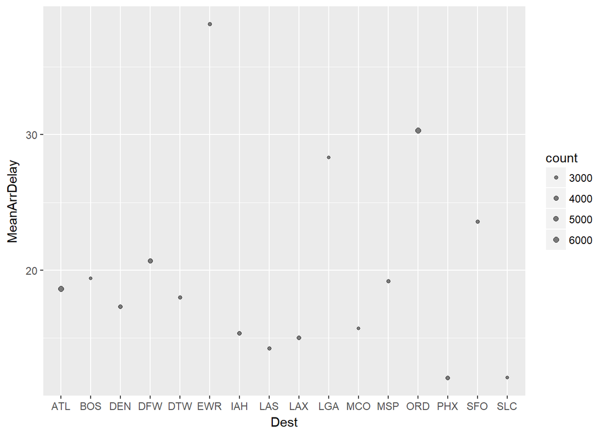

```r
ggplot(DestAirportDelay, aes(Dest, MeanArrDelay)) + geom_point(aes(size=count), alpha=1/2) + geom_smooth() + scale_size_area(max_size = 2)
```

### Let’s plot continous variables and see how they are co-related to each other and to Airline delays.

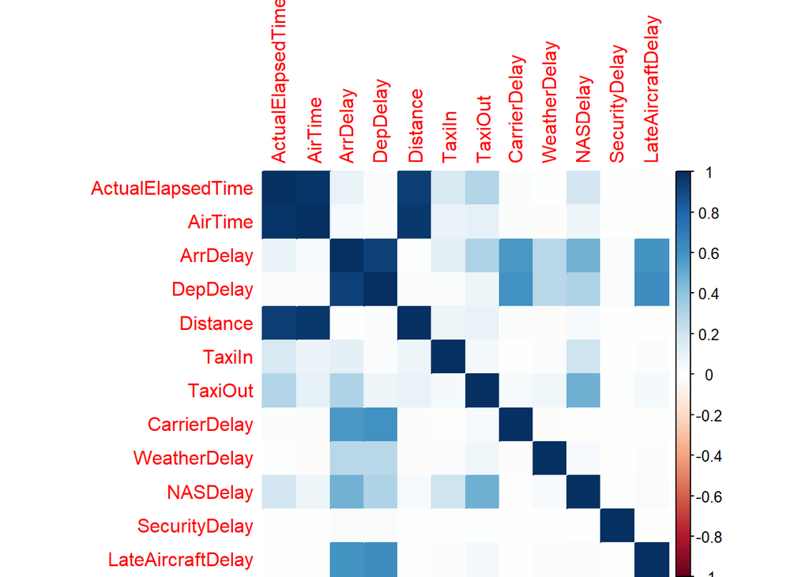

```r
continousdelay <- select(tripsplaneairports, ActualElapsedTime, AirTime, ArrDelay, DepDelay, Distance,
                         TaxiIn, TaxiOut, CarrierDelay, WeatherDelay, NASDelay, SecurityDelay, LateAircraftDelay)

tripscorr <- cor(continousdelay, method="pearson")
# Let's plot the co-relation matix
corrplot(tripscorr, method="color")
```

### co-relation matix

corrplot(tripscorr, method=“color”)

This clearly provides co-relation between the variables. Now based on exploratory data analysis, we need to choose the variables that are potentially significant and then start the modeling. Based on this plot, we can see ArrDelay has positive co-relation with DepDelay, TaxiOut, CarrierDelay, NASDelay, WeatherDelay, LateAirCraftDelay And DepDelay has positive co-relation wth TaxiOut, CarrierDelay, NASDelay, WeatherDelay, LateAirCraftDelay So, from continous variable point of view, we got the starting point. We can also see that the significant variables are not co-related to each other. i.e there is no multico-linearity.

#### If the multi-colinirity is present, then we should have addressed. i.e combining variables or picking only most significant one and leaving other. PCA is one of the method to address the same. We don’t need here.

Now we have fair idea, now let us see variable significane and based on the results we can choose the best variable combination. We can also statistically, prove what we saw visually befor choosing the final machine learning model.

```r
modeltrips <- na.omit(tripsplaneairports[,c("Dest","Origin", "Month", "DayOfWeek",  "ArrTime", "UniqueCarrier", "ActualElapsedTime", "CRSElapsedTime",
                                    "TaxiOut", "Diverted",  "CarrierDelay", "WeatherDelay",    "NASDelay",        "SecurityDelay",   "LateAircraftDelay" ,"ArrHour",
                                    "DepHour",         "ArrTimeofday",    "DepTimeofday",       "WeekOfMonth",    "Origincity",
                                    "Originstate",   "Destcity", "Deststate" ,  "ArrDelay", "DepDelay" )])
```

#### See each variable, how significant to the DepDelay and ArrDelay

```r
lm.fit1 <- stats::lm(formula = DepDelay ~ factor(Month), data = modeltrips)
summary(lm.fit1)
```

```
##
## Call:
## stats::lm(formula = DepDelay ~ factor(Month), data = modeltrips)
##
## Residuals:
##     Min      1Q  Median      3Q     Max
##  -67.41  -21.74  -14.67    3.59 1476.81
##
## Coefficients:
##                 Estimate Std. Error t value Pr(>|t|)
## (Intercept)      18.4173     0.4350  42.335  < 2e-16 ***
## factor(Month)2    3.9889     0.6297   6.335 2.38e-10 ***
## factor(Month)3    1.3241     0.6120   2.164 0.030499 *
## factor(Month)4   -2.2021     0.6228  -3.536 0.000407 ***
## factor(Month)5   -4.1822     0.6215  -6.730 1.71e-11 ***
## factor(Month)6    6.0024     0.6127   9.797  < 2e-16 ***
## factor(Month)7    3.5181     0.6101   5.766 8.13e-09 ***
## factor(Month)8    1.4151     0.6158   2.298 0.021566 *
## factor(Month)9   -8.2280     0.6404 -12.848  < 2e-16 ***
## factor(Month)10  -6.7474     0.6301 -10.708  < 2e-16 ***
## factor(Month)11  -6.3326     0.6329 -10.005  < 2e-16 ***
## factor(Month)12   6.5672     0.6161  10.659  < 2e-16 ***
## ---
## Signif. codes:  0 '***' 0.001 '**' 0.01 '*' 0.05 '.' 0.1 ' ' 1
##
## Residual standard error: 44.14 on 118943 degrees of freedom
## Multiple R-squared:  0.01172,    Adjusted R-squared:  0.01163
## F-statistic: 128.2 on 11 and 118943 DF,  p-value: < 2.2e-16
```

Month seems to be significant as evident in EDA and here with p value less than 0.0001.

```r
lm.fit2 <-  stats::lm(formula = DepDelay ~ factor(DepTimeofday) + factor(DepHour), data = modeltrips)
summary(lm.fit2)
```

```
##
## Call:
## stats::lm(formula = DepDelay ~ factor(DepTimeofday) + factor(DepHour),
##     data = modeltrips)
##
## Residuals:
##     Min      1Q  Median      3Q     Max
##  -63.55  -21.35  -12.07    2.90 1476.00
##
## Coefficients: (3 not defined because of singularities)
##                       Estimate Std. Error t value Pr(>|t|)
## (Intercept)            11.5337     3.4286   3.364 0.000769 ***
## factor(DepTimeofday)1   2.8195     3.4640   0.814 0.415691
## factor(DepTimeofday)2  14.4063     3.4624   4.161 3.17e-05 ***
## factor(DepTimeofday)3   6.1122     3.8692   1.580 0.114173
## factor(DepHour)1       -5.4087     7.1886  -0.752 0.451807
## factor(DepHour)2       -1.9883    13.6364  -0.146 0.884074
## factor(DepHour)3       23.1805    16.8965   1.372 0.170093
## factor(DepHour)4       -5.8909    12.1911  -0.483 0.628947
## factor(DepHour)5       -4.1211     3.8080  -1.082 0.279151
## factor(DepHour)6       -8.7516     0.7046 -12.421  < 2e-16 ***
## factor(DepHour)7       -6.7473     0.7061  -9.555  < 2e-16 ***
## factor(DepHour)8       -5.6597     0.6986  -8.102 5.45e-16 ***
## factor(DepHour)9       -3.3503     0.7056  -4.748 2.06e-06 ***
## factor(DepHour)10      -0.8304     0.7114  -1.167 0.243114
## factor(DepHour)11           NA         NA      NA       NA
## factor(DepHour)12      -9.3160     0.7024 -13.262  < 2e-16 ***
## factor(DepHour)13      -7.3917     0.6904 -10.706  < 2e-16 ***
## factor(DepHour)14      -4.8717     0.7005  -6.955 3.55e-12 ***
## factor(DepHour)15      -4.2743     0.7005  -6.102 1.05e-09 ***
## factor(DepHour)16      -0.7852     0.6877  -1.142 0.253542
## factor(DepHour)17           NA         NA      NA       NA
## factor(DepHour)18       9.4685     1.8633   5.082 3.75e-07 ***
## factor(DepHour)19       9.7376     1.8643   5.223 1.76e-07 ***
## factor(DepHour)20      11.5021     1.8971   6.063 1.34e-09 ***
## factor(DepHour)21       8.4500     1.9155   4.411 1.03e-05 ***
## factor(DepHour)22       1.3281     2.1265   0.625 0.532272
## factor(DepHour)23           NA         NA      NA       NA
## ---
## Signif. codes:  0 '***' 0.001 '**' 0.01 '*' 0.05 '.' 0.1 ' ' 1
##
## Residual standard error: 43.77 on 118931 degrees of freedom
## Multiple R-squared:  0.02835,    Adjusted R-squared:  0.02817
## F-statistic: 150.9 on 23 and 118931 DF,  p-value: < 2.2e-16
```

Both seems to be signifiant

```r
lm.fit3 <-  stats::lm(formula = DepDelay ~ factor(DepTimeofday) , data = modeltrips)
summary(lm.fit3)
```

```
##
## Call:
## stats::lm(formula = DepDelay ~ factor(DepTimeofday), data = modeltrips)
##
## Residuals:
##     Min      1Q  Median      3Q     Max
##  -66.60  -21.60  -12.60    3.26 1476.87
##
## Coefficients:
##                       Estimate Std. Error t value Pr(>|t|)
## (Intercept)              8.262      1.430   5.776 7.66e-09 ***
## factor(DepTimeofday)1    1.865      1.445   1.291    0.197
## factor(DepTimeofday)2   13.341      1.445   9.233  < 2e-16 ***
## factor(DepTimeofday)3   18.478      1.456  12.691  < 2e-16 ***
## ---
## Signif. codes:  0 '***' 0.001 '**' 0.01 '*' 0.05 '.' 0.1 ' ' 1
##
## Residual standard error: 43.88 on 118951 degrees of freedom
## Multiple R-squared:  0.02348,    Adjusted R-squared:  0.02346
## F-statistic: 953.5 on 3 and 118951 DF,  p-value: < 2.2e-16
```

This seems to be significant

```r
lm.fit4 <-  stats::lm(formula = DepDelay ~ factor(DepHour) , data = modeltrips)
summary(lm.fit4)
```

```
##
## Call:
## stats::lm(formula = DepDelay ~ factor(DepHour), data = modeltrips)
##
## Residuals:
##     Min      1Q  Median      3Q     Max
##  -63.55  -21.35  -12.07    2.90 1476.00
##
## Coefficients:
##                   Estimate Std. Error t value Pr(>|t|)
## (Intercept)        11.5337     3.4286   3.364 0.000769 ***
## factor(DepHour)1   -5.4087     7.1886  -0.752 0.451807
## factor(DepHour)2   -1.9883    13.6364  -0.146 0.884074
## factor(DepHour)3   23.1805    16.8965   1.372 0.170093
## factor(DepHour)4   -5.8909    12.1911  -0.483 0.628947
## factor(DepHour)5   -4.1211     3.8080  -1.082 0.279151
## factor(DepHour)6   -5.9321     3.4653  -1.712 0.086921 .
## factor(DepHour)7   -3.9279     3.4656  -1.133 0.257047
## factor(DepHour)8   -2.8402     3.4640  -0.820 0.412261
## factor(DepHour)9   -0.5308     3.4655  -0.153 0.878260
## factor(DepHour)10   1.9890     3.4667   0.574 0.566130
## factor(DepHour)11   2.8195     3.4640   0.814 0.415691
## factor(DepHour)12   5.0903     3.4665   1.468 0.141990
## factor(DepHour)13   7.0146     3.4641   2.025 0.042873 *
## factor(DepHour)14   9.5346     3.4661   2.751 0.005946 **
## factor(DepHour)15  10.1320     3.4661   2.923 0.003465 **
## factor(DepHour)16  13.6211     3.4635   3.933 8.40e-05 ***
## factor(DepHour)17  14.4063     3.4624   4.161 3.17e-05 ***
## factor(DepHour)18  15.5808     3.4659   4.495 6.95e-06 ***
## factor(DepHour)19  15.8498     3.4665   4.572 4.83e-06 ***
## factor(DepHour)20  17.6143     3.4842   5.056 4.30e-07 ***
## factor(DepHour)21  14.5622     3.4942   4.168 3.08e-05 ***
## factor(DepHour)22   7.4403     3.6142   2.059 0.039532 *
## factor(DepHour)23   6.1122     3.8692   1.580 0.114173
## ---
## Signif. codes:  0 '***' 0.001 '**' 0.01 '*' 0.05 '.' 0.1 ' ' 1
##
## Residual standard error: 43.77 on 118931 degrees of freedom
## Multiple R-squared:  0.02835,    Adjusted R-squared:  0.02817
## F-statistic: 150.9 on 23 and 118931 DF,  p-value: < 2.2e-16
```

Dep hour seems to be more significant

```r
lm.fit5 <-  stats::lm(formula = DepDelay ~ factor(DayOfWeek) + factor(WeekOfMonth), data = modeltrips)
summary(lm.fit5)
```

```
##
## Call:
## stats::lm(formula = DepDelay ~ factor(DayOfWeek) + factor(WeekOfMonth),
##     data = modeltrips)
##
## Residuals:
##     Min      1Q  Median      3Q     Max
##  -64.27  -21.52  -16.57    4.07 1468.66
##
## Coefficients:
##                      Estimate Std. Error t value Pr(>|t|)
## (Intercept)           17.7017     0.4220  41.944  < 2e-16 ***
## factor(DayOfWeek)2    -2.4654     0.4749  -5.192 2.09e-07 ***
## factor(DayOfWeek)3    -2.4244     0.4746  -5.109 3.25e-07 ***
## factor(DayOfWeek)4     0.4021     0.4730   0.850 0.395227
## factor(DayOfWeek)5     1.5709     0.4702   3.341 0.000835 ***
## factor(DayOfWeek)6    -3.5753     0.4969  -7.196 6.25e-13 ***
## factor(DayOfWeek)7     0.6464     0.4787   1.350 0.176919
## factor(WeekOfMonth)2   0.6379     0.3945   1.617 0.105845
## factor(WeekOfMonth)3   2.4457     0.3962   6.173 6.71e-10 ***
## factor(WeekOfMonth)4   2.2415     0.3962   5.658 1.53e-08 ***
## factor(WeekOfMonth)5   0.4535     0.4828   0.939 0.347517
## ---
## Signif. codes:  0 '***' 0.001 '**' 0.01 '*' 0.05 '.' 0.1 ' ' 1
##
## Residual standard error: 44.36 on 118944 degrees of freedom
## Multiple R-squared:  0.002124,   Adjusted R-squared:  0.002041
## F-statistic: 25.32 on 10 and 118944 DF,  p-value: < 2.2e-16
```

The variance it is explaining is very small.

Now let’s combine by adding these together and check significance.

```r
lm.fit.com.1 <- stats::lm(formula = DepDelay ~ factor(Month) + factor(WeekOfMonth)  , data = modeltrips)
summary(lm.fit.com.1)
```

```
##
## Call:
## stats::lm(formula = DepDelay ~ factor(Month) + factor(WeekOfMonth),
##     data = modeltrips)
##
## Residuals:
##     Min      1Q  Median      3Q     Max
##  -66.15  -21.68  -14.57    3.76 1477.38
##
## Coefficients:
##                      Estimate Std. Error t value Pr(>|t|)
## (Intercept)           17.2442     0.5055  34.116  < 2e-16 ***
## factor(Month)2         3.9091     0.6305   6.200 5.67e-10 ***
## factor(Month)3         1.3258     0.6119   2.167 0.030263 *
## factor(Month)4        -2.1899     0.6229  -3.516 0.000439 ***
## factor(Month)5        -4.1820     0.6214  -6.730 1.70e-11 ***
## factor(Month)6         5.9592     0.6127   9.726  < 2e-16 ***
## factor(Month)7         3.5020     0.6101   5.740 9.49e-09 ***
## factor(Month)8         1.4277     0.6158   2.318 0.020424 *
## factor(Month)9        -8.2407     0.6405 -12.867  < 2e-16 ***
## factor(Month)10       -6.7592     0.6300 -10.728  < 2e-16 ***
## factor(Month)11       -6.3293     0.6329 -10.000  < 2e-16 ***
## factor(Month)12        6.5000     0.6161  10.550  < 2e-16 ***
## factor(WeekOfMonth)2   0.6159     0.3925   1.569 0.116586
## factor(WeekOfMonth)3   2.2528     0.3942   5.715 1.10e-08 ***
## factor(WeekOfMonth)4   2.0611     0.3942   5.229 1.71e-07 ***
## factor(WeekOfMonth)5   0.4944     0.4809   1.028 0.303870
## ---
## Signif. codes:  0 '***' 0.001 '**' 0.01 '*' 0.05 '.' 0.1 ' ' 1
##
## Residual standard error: 44.14 on 118939 degrees of freedom
## Multiple R-squared:  0.01215,    Adjusted R-squared:  0.01202
## F-statistic:  97.5 on 15 and 118939 DF,  p-value: < 2.2e-16
```

Increase in R-Squared is not visible ~ 0.1%

```r
lm.fit.com.2 <- stats::lm(formula = DepDelay ~ factor(Month) + factor(WeekOfMonth) + factor(DayOfWeek) , data = modeltrips)
summary(lm.fit.com.2)
```

```
##
## Call:
## stats::lm(formula = DepDelay ~ factor(Month) + factor(WeekOfMonth) +
##     factor(DayOfWeek), data = modeltrips)
##
## Residuals:
##     Min      1Q  Median      3Q     Max
##  -68.40  -21.60  -14.44    3.63 1476.72
##
## Coefficients:
##                      Estimate Std. Error t value Pr(>|t|)
## (Intercept)           17.9989     0.5887  30.572  < 2e-16 ***
## factor(Month)2         3.7801     0.6302   5.998 2.00e-09 ***
## factor(Month)3         1.2239     0.6120   2.000 0.045534 *
## factor(Month)4        -2.3161     0.6228  -3.719 0.000200 ***
## factor(Month)5        -4.2149     0.6211  -6.787 1.15e-11 ***
## factor(Month)6         5.8582     0.6128   9.560  < 2e-16 ***
## factor(Month)7         3.4239     0.6099   5.614 1.98e-08 ***
## factor(Month)8         1.3131     0.6157   2.133 0.032949 *
## factor(Month)9        -8.3314     0.6405 -13.009  < 2e-16 ***
## factor(Month)10       -6.8033     0.6296 -10.806  < 2e-16 ***
## factor(Month)11       -6.4824     0.6328 -10.244  < 2e-16 ***
## factor(Month)12        6.4413     0.6160  10.456  < 2e-16 ***
## factor(WeekOfMonth)2   0.6115     0.3922   1.559 0.118993
## factor(WeekOfMonth)3   2.2640     0.3940   5.747 9.12e-09 ***
## factor(WeekOfMonth)4   2.0648     0.3940   5.241 1.60e-07 ***
## factor(WeekOfMonth)5   0.5214     0.4809   1.084 0.278288
## factor(DayOfWeek)2    -2.3002     0.4724  -4.870 1.12e-06 ***
## factor(DayOfWeek)3    -2.2595     0.4722  -4.785 1.71e-06 ***
## factor(DayOfWeek)4     0.6020     0.4707   1.279 0.200880
## factor(DayOfWeek)5     1.6227     0.4680   3.468 0.000525 ***
## factor(DayOfWeek)6    -3.6080     0.4944  -7.298 2.94e-13 ***
## factor(DayOfWeek)7     0.6743     0.4761   1.416 0.156656
## ---
## Signif. codes:  0 '***' 0.001 '**' 0.01 '*' 0.05 '.' 0.1 ' ' 1
##
## Residual standard error: 44.1 on 118933 degrees of freedom
## Multiple R-squared:  0.01375,    Adjusted R-squared:  0.01357
## F-statistic: 78.95 on 21 and 118933 DF,  p-value: < 2.2e-16
```

```r
lm.fit.com.3 <- stats::lm(formula = DepDelay ~  factor(Month) + factor(DepHour) , data = modeltrips)
summary(lm.fit.com.3)
```

```
##
## Call:
## stats::lm(formula = DepDelay ~ factor(Month) + factor(DepHour),
##     data = modeltrips)
##
## Residuals:
##     Min      1Q  Median      3Q     Max
##  -67.64  -21.07  -11.83    2.86 1483.86
##
## Coefficients:
##                   Estimate Std. Error t value Pr(>|t|)
## (Intercept)       11.05494    3.43640   3.217  0.00130 **
## factor(Month)2     3.96349    0.62088   6.384 1.74e-10 ***
## factor(Month)3     1.41337    0.60343   2.342  0.01917 *
## factor(Month)4    -1.94577    0.61416  -3.168  0.00153 **
## factor(Month)5    -4.18543    0.61278  -6.830 8.52e-12 ***
## factor(Month)6     5.84740    0.60412   9.679  < 2e-16 ***
## factor(Month)7     3.37528    0.60161   5.610 2.02e-08 ***
## factor(Month)8     1.39196    0.60718   2.293  0.02188 *
## factor(Month)9    -7.95622    0.63149 -12.599  < 2e-16 ***
## factor(Month)10   -6.53849    0.62133 -10.523  < 2e-16 ***
## factor(Month)11   -5.93200    0.62415  -9.504  < 2e-16 ***
## factor(Month)12    6.79163    0.60754  11.179  < 2e-16 ***
## factor(DepHour)1  -5.45680    7.14744  -0.763  0.44519
## factor(DepHour)2  -4.11008   13.55888  -0.303  0.76179
## factor(DepHour)3  24.73800   16.80070   1.472  0.14091
## factor(DepHour)4  -3.44295   12.12192  -0.284  0.77639
## factor(DepHour)5  -3.58391    3.78627  -0.947  0.34387
## factor(DepHour)6  -5.15484    3.44560  -1.496  0.13464
## factor(DepHour)7  -3.22745    3.44594  -0.937  0.34897
## factor(DepHour)8  -2.16494    3.44439  -0.629  0.52965
## factor(DepHour)9   0.04533    3.44579   0.013  0.98950
## factor(DepHour)10  2.61910    3.44696   0.760  0.44736
## factor(DepHour)11  3.47112    3.44436   1.008  0.31357
## factor(DepHour)12  5.67301    3.44679   1.646  0.09979 .
## factor(DepHour)13  7.62212    3.44442   2.213  0.02691 *
## factor(DepHour)14 10.10577    3.44640   2.932  0.00337 **
## factor(DepHour)15 10.75415    3.44639   3.120  0.00181 **
## factor(DepHour)16 14.17160    3.44383   4.115 3.87e-05 ***
## factor(DepHour)17 14.92090    3.44273   4.334 1.47e-05 ***
## factor(DepHour)18 16.16718    3.44621   4.691 2.72e-06 ***
## factor(DepHour)19 16.39239    3.44675   4.756 1.98e-06 ***
## factor(DepHour)20 18.07086    3.46434   5.216 1.83e-07 ***
## factor(DepHour)21 14.96746    3.47438   4.308 1.65e-05 ***
## factor(DepHour)22  7.86288    3.59366   2.188  0.02867 *
## factor(DepHour)23  6.27791    3.84714   1.632  0.10272
## ---
## Signif. codes:  0 '***' 0.001 '**' 0.01 '*' 0.05 '.' 0.1 ' ' 1
##
## Residual standard error: 43.52 on 118920 degrees of freedom
## Multiple R-squared:  0.03957,    Adjusted R-squared:  0.0393
## F-statistic: 144.1 on 34 and 118920 DF,  p-value: < 2.2e-16
```

Out of above variables, Month adn DepHour seems to be predicting better.

```r
lm.fit.com.3 <- stats::lm(formula = DepDelay ~  factor(Month) +  factor(ArrHour) , data = modeltrips)
summary(lm.fit.com.3)
```

```
##
## Call:
## stats::lm(formula = DepDelay ~ factor(Month) + factor(ArrHour),
##     data = modeltrips)
##
## Residuals:
##     Min      1Q  Median      3Q     Max
##  -69.26  -21.01  -11.74    2.87 1471.39
##
## Coefficients:
##                   Estimate Std. Error t value Pr(>|t|)
## (Intercept)        28.7160     1.5403  18.643  < 2e-16 ***
## factor(Month)2      3.9653     0.6206   6.389 1.67e-10 ***
## factor(Month)3      1.3864     0.6032   2.299 0.021533 *
## factor(Month)4     -1.9812     0.6139  -3.227 0.001251 **
## factor(Month)5     -4.1621     0.6125  -6.795 1.09e-11 ***
## factor(Month)6      5.8596     0.6039   9.703  < 2e-16 ***
## factor(Month)7      3.4122     0.6014   5.674 1.40e-08 ***
## factor(Month)8      1.4463     0.6070   2.383 0.017181 *
## factor(Month)9     -7.9623     0.6313 -12.613  < 2e-16 ***
## factor(Month)10    -6.5613     0.6211 -10.564  < 2e-16 ***
## factor(Month)11    -5.9411     0.6239  -9.523  < 2e-16 ***
## factor(Month)12     6.7011     0.6073  11.035  < 2e-16 ***
## factor(ArrHour)1   -7.2088     3.7666  -1.914 0.055636 .
## factor(ArrHour)2   -9.7776     6.7251  -1.454 0.145976
## factor(ArrHour)3  -10.3267     9.8414  -1.049 0.294035
## factor(ArrHour)4  -18.0954     4.9211  -3.677 0.000236 ***
## factor(ArrHour)5  -13.7674     2.3154  -5.946 2.76e-09 ***
## factor(ArrHour)6  -16.8142     1.9841  -8.475  < 2e-16 ***
## factor(ArrHour)7  -22.4783     1.6505 -13.619  < 2e-16 ***
## factor(ArrHour)8  -21.8475     1.5963 -13.687  < 2e-16 ***
## factor(ArrHour)9  -20.4566     1.5816 -12.934  < 2e-16 ***
## factor(ArrHour)10 -19.9654     1.5676 -12.736  < 2e-16 ***
## factor(ArrHour)11 -18.2885     1.5728 -11.628  < 2e-16 ***
## factor(ArrHour)12 -16.6963     1.5675 -10.652  < 2e-16 ***
## factor(ArrHour)13 -14.1704     1.5750  -8.997  < 2e-16 ***
## factor(ArrHour)14 -12.4869     1.5692  -7.958 1.77e-15 ***
## factor(ArrHour)15 -10.4109     1.5695  -6.633 3.29e-11 ***
## factor(ArrHour)16  -8.4263     1.5604  -5.400 6.68e-08 ***
## factor(ArrHour)17  -5.1456     1.5656  -3.287 0.001014 **
## factor(ArrHour)18  -4.7711     1.5616  -3.055 0.002249 **
## factor(ArrHour)19  -2.3938     1.5688  -1.526 0.127054
## factor(ArrHour)20  -1.7784     1.5589  -1.141 0.253970
## factor(ArrHour)21  -1.3899     1.5762  -0.882 0.377882
## factor(ArrHour)22  -0.4987     1.5884  -0.314 0.753575
## factor(ArrHour)23  -1.0306     1.6419  -0.628 0.530211
## ---
## Signif. codes:  0 '***' 0.001 '**' 0.01 '*' 0.05 '.' 0.1 ' ' 1
##
## Residual standard error: 43.51 on 118920 degrees of freedom
## Multiple R-squared:  0.04029,    Adjusted R-squared:  0.04002
## F-statistic: 146.8 on 34 and 118920 DF,  p-value: < 2.2e-16
```

Very different insight. Scheduled ArrHour is better predictor to DepDelay then compared with Secheduled DepHour. The difference is not huge though.

```r
lm.fit6 <-  stats::lm(formula = DepDelay ~ factor(UniqueCarrier),  data = modeltrips)
summary(lm.fit6)
```

```
##
## Call:
## stats::lm(formula = DepDelay ~ factor(UniqueCarrier), data = modeltrips)
##
## Residuals:
##     Min      1Q  Median      3Q     Max
##  -65.06  -21.56  -15.80    4.14 1473.39
##
## Coefficients:
##                         Estimate Std. Error t value Pr(>|t|)
## (Intercept)              16.2825     0.6929  23.498  < 2e-16 ***
## factor(UniqueCarrier)AA   5.4565     0.8151   6.694 2.18e-11 ***
## factor(UniqueCarrier)AQ -15.3326     1.9095  -8.030 9.87e-16 ***
## factor(UniqueCarrier)AS  -1.4451     1.1217  -1.288 0.197638
## factor(UniqueCarrier)B6   7.4585     1.0356   7.202 5.95e-13 ***
## factor(UniqueCarrier)CO   3.9573     0.9230   4.287 1.81e-05 ***
## factor(UniqueCarrier)DL  -3.4799     0.8605  -4.044 5.26e-05 ***
## factor(UniqueCarrier)EV  10.7030     0.9553  11.204  < 2e-16 ***
## factor(UniqueCarrier)F9  -4.6281     1.3235  -3.497 0.000471 ***
## factor(UniqueCarrier)FL   0.1540     0.9685   0.159 0.873662
## factor(UniqueCarrier)HA -13.7453     1.6704  -8.229  < 2e-16 ***
## factor(UniqueCarrier)MQ   4.5754     0.8434   5.425 5.80e-08 ***
## factor(UniqueCarrier)NW  -2.6689     0.8855  -3.014 0.002578 **
## factor(UniqueCarrier)OH   1.6457     1.0034   1.640 0.100995
## factor(UniqueCarrier)OO  -0.7229     0.8325  -0.868 0.385239
## factor(UniqueCarrier)UA   6.1845     0.8506   7.271 3.59e-13 ***
## factor(UniqueCarrier)US   0.9822     0.8612   1.140 0.254094
## factor(UniqueCarrier)WN   0.6857     0.7636   0.898 0.369168
## factor(UniqueCarrier)XE   3.9355     0.8722   4.512 6.42e-06 ***
## factor(UniqueCarrier)YV   3.7772     0.9545   3.957 7.59e-05 ***
## ---
## Signif. codes:  0 '***' 0.001 '**' 0.01 '*' 0.05 '.' 0.1 ' ' 1
##
## Residual standard error: 44.23 on 118935 degrees of freedom
## Multiple R-squared:  0.007778,   Adjusted R-squared:  0.00762
## F-statistic: 49.07 on 19 and 118935 DF,  p-value: < 2.2e-16
```

Through p-value they seem to be significant, not when we look for R-squared. Let’s proceed further.

```r
lm.fit7 <-  stats::lm(formula = DepDelay ~ factor(Originstate) ,  data = modeltrips)
summary(lm.fit7)
```

```
##
## Call:
## stats::lm(formula = DepDelay ~ factor(Originstate), data = modeltrips)
##
## Residuals:
##     Min      1Q  Median      3Q     Max
##  -71.39  -21.49  -15.70    4.02 1469.10
##
## Coefficients:
##                        Estimate Std. Error t value Pr(>|t|)
## (Intercept)            17.90032    1.77335  10.094  < 2e-16 ***
## factor(Originstate)AL  -2.26065    2.40510  -0.940 0.347251
## factor(Originstate)AR   5.21733    2.61848   1.993 0.046318 *
## factor(Originstate)AZ  -2.90293    1.91155  -1.519 0.128860
## factor(Originstate)CA  -3.05206    1.81272  -1.684 0.092245 .
## factor(Originstate)CO   0.10645    1.89001   0.056 0.955084
## factor(Originstate)CT  -0.08925    2.62253  -0.034 0.972851
## factor(Originstate)DE  29.67111   16.81011   1.765 0.077554 .
## factor(Originstate)FL   0.81277    1.84266   0.441 0.659151
## factor(Originstate)GA   3.17476    1.84912   1.717 0.086001 .
## factor(Originstate)HI -14.49733    2.03816  -7.113 1.14e-12 ***
## factor(Originstate)IA   5.03926    2.68698   1.875 0.060735 .
## factor(Originstate)ID  -9.32922    2.74958  -3.393 0.000692 ***
## factor(Originstate)IL   8.49386    1.83847   4.620 3.84e-06 ***
## factor(Originstate)IN   0.94195    2.28987   0.411 0.680812
## factor(Originstate)KS  -0.68806    3.51730  -0.196 0.844907
## factor(Originstate)KY  -3.21155    2.01296  -1.595 0.110618
## factor(Originstate)LA  -0.62127    2.22135  -0.280 0.779721
## factor(Originstate)MA   0.08994    2.02424   0.044 0.964562
## factor(Originstate)MD  -0.71608    2.07450  -0.345 0.729959
## factor(Originstate)ME   3.82268    3.51114   1.089 0.276275
## factor(Originstate)MI  -1.34631    1.92041  -0.701 0.483271
## factor(Originstate)MN  -2.81889    1.97845  -1.425 0.154218
## factor(Originstate)MO  -0.84898    2.00449  -0.424 0.671903
## factor(Originstate)MS   5.73579    2.92886   1.958 0.050189 .
## factor(Originstate)MT  -8.82100    2.94720  -2.993 0.002763 **
## factor(Originstate)NC   0.74862    1.91931   0.390 0.696505
## factor(Originstate)ND  -3.73258    3.97044  -0.940 0.347172
## factor(Originstate)NE   2.13943    2.69015   0.795 0.426451
## factor(Originstate)NH  -1.66303    2.94454  -0.565 0.572221
```

[output cut: 13 more lines]

```
## factor(Originstate)TX   0.58591    1.81587   0.323 0.746954
## factor(Originstate)UT  -5.91555    1.99890  -2.959 0.003083 **
## factor(Originstate)VA   0.56443    1.91707   0.294 0.768435
## factor(Originstate)VI   2.87746    6.27438   0.459 0.646519
## factor(Originstate)VT  14.71786    4.57460   3.217 0.001294 **
## factor(Originstate)WA  -3.12918    2.02927  -1.542 0.123070
## factor(Originstate)WI   1.86243    2.27600   0.818 0.413195
## factor(Originstate)WV   0.89655    5.80586   0.154 0.877277
## factor(Originstate)WY  -8.62060    4.10163  -2.102 0.035577 *
## ---
## Signif. codes:  0 '***' 0.001 '**' 0.01 '*' 0.05 '.' 0.1 ' ' 1
##
## Residual standard error: 44.23 on 118903 degrees of freedom
## Multiple R-squared:  0.008362,   Adjusted R-squared:  0.007936
## F-statistic: 19.66 on 51 and 118903 DF,  p-value: < 2.2e-16
```

Seems to have some significance

```r
lm.fit7a <-  stats::lm(formula = DepDelay ~  factor(Deststate),  data = modeltrips)
summary(lm.fit7a)
```

```
##
## Call:
## stats::lm(formula = DepDelay ~ factor(Deststate), data = modeltrips)
##
## Residuals:
##     Min      1Q  Median      3Q     Max
##  -63.71  -21.13  -15.78    4.14 1470.80
##
## Coefficients:
##                     Estimate Std. Error t value Pr(>|t|)
## (Intercept)          16.7843     1.7167   9.777  < 2e-16 ***
## factor(Deststate)AL  -0.4745     2.3668  -0.200 0.841096
## factor(Deststate)AR   5.7945     2.5166   2.302 0.021309 *
## factor(Deststate)AZ  -2.8702     1.8584  -1.544 0.122498
## factor(Deststate)CA  -1.0063     1.7560  -0.573 0.566594
## factor(Deststate)CO  -0.8441     1.8379  -0.459 0.646053
## factor(Deststate)CT   1.0038     2.6108   0.384 0.700622
## factor(Deststate)DE  17.2157    19.8427   0.868 0.385611
## factor(Deststate)FL   1.0860     1.7885   0.607 0.543717
## factor(Deststate)GA   1.0139     1.7953   0.565 0.572248
## factor(Deststate)HI -10.7300     1.9822  -5.413 6.20e-08 ***
## factor(Deststate)IA   1.0349     2.6050   0.397 0.691151
## factor(Deststate)ID  -1.7221     2.7942  -0.616 0.537685
## factor(Deststate)IL   8.5035     1.7868   4.759 1.95e-06 ***
## factor(Deststate)IN   3.0002     2.2210   1.351 0.176744
## factor(Deststate)KS   2.4021     3.3506   0.717 0.473421
## factor(Deststate)KY  -0.6535     1.9521  -0.335 0.737790
## factor(Deststate)LA   1.1986     2.1678   0.553 0.580317
## factor(Deststate)MA   2.4382     1.9750   1.235 0.217005
## factor(Deststate)MD   1.7190     2.0286   0.847 0.396779
## factor(Deststate)ME   9.9538     3.5002   2.844 0.004459 **
## factor(Deststate)MI   0.2110     1.8763   0.112 0.910468
## factor(Deststate)MN  -0.5863     1.9352  -0.303 0.761925
## factor(Deststate)MO  -0.7428     1.9565  -0.380 0.704193
## factor(Deststate)MS   3.7291     2.8586   1.305 0.192062
## factor(Deststate)MT  -3.7869     2.8370  -1.335 0.181938
## factor(Deststate)NC  -0.3465     1.8747  -0.185 0.853382
## factor(Deststate)ND  -2.6757     3.7566  -0.712 0.476300
## factor(Deststate)NE   4.4943     2.5370   1.772 0.076480 .
## factor(Deststate)NH   3.1115     2.9071   1.070 0.284485
```

[output cut: 13 more lines]

```
## factor(Deststate)TX   0.6434     1.7618   0.365 0.714950
## factor(Deststate)UT  -4.9269     1.9518  -2.524 0.011594 *
## factor(Deststate)VA   1.9227     1.8641   1.031 0.302336
## factor(Deststate)VI  -4.6089     6.1014  -0.755 0.450019
## factor(Deststate)VT   7.7792     4.2959   1.811 0.070166 .
## factor(Deststate)WA  -1.2097     1.9559  -0.618 0.536270
## factor(Deststate)WI   4.2157     2.2233   1.896 0.057941 .
## factor(Deststate)WV   3.9915     6.0527   0.659 0.509600
## factor(Deststate)WY   6.0339     4.3698   1.381 0.167341
## ---
## Signif. codes:  0 '***' 0.001 '**' 0.01 '*' 0.05 '.' 0.1 ' ' 1
##
## Residual standard error: 44.2 on 118903 degrees of freedom
## Multiple R-squared:  0.009435,   Adjusted R-squared:  0.00901
## F-statistic: 22.21 on 51 and 118903 DF,  p-value: < 2.2e-16
```

Seems to have some significance

```r
lm.fit7c <-  stats::lm(formula = DepDelay ~ factor(Originstate) + factor(Deststate),  data = modeltrips)
summary(lm.fit7c)
```

```
##
## Call:
## stats::lm(formula = DepDelay ~ factor(Originstate) + factor(Deststate),
##     data = modeltrips)
##
## Residuals:
##     Min      1Q  Median      3Q     Max
##  -68.33  -20.99  -14.81    4.27 1470.22
##
## Coefficients:
##                         Estimate Std. Error t value Pr(>|t|)
## (Intercept)            17.962120   1.944326   9.238  < 2e-16 ***
## factor(Originstate)AL  -3.094248   2.832307  -1.092 0.274623
## factor(Originstate)AR   3.538650   3.013970   1.174 0.240364
## factor(Originstate)AZ  -3.126577   2.411147  -1.297 0.194731
## factor(Originstate)CA  -3.275554   2.333711  -1.404 0.160446
## factor(Originstate)CO  -0.194605   2.396231  -0.081 0.935273
## factor(Originstate)CT  -1.943760   3.018363  -0.644 0.519591
## factor(Originstate)DE  29.613266  16.830422   1.760 0.078494 .
## factor(Originstate)FL  -1.239304   2.374721  -0.522 0.601759
## factor(Originstate)GA   2.057342   2.377339   0.865 0.386823
## factor(Originstate)HI -14.002278   2.769863  -5.055 4.31e-07 ***
## factor(Originstate)IA   2.583867   3.073029   0.841 0.400450
## factor(Originstate)ID  -8.031211   3.136784  -2.560 0.010458 *
## factor(Originstate)IL   7.448984   2.362719   3.153 0.001618 **
## factor(Originstate)IN  -0.858137   2.733337  -0.314 0.753558
## factor(Originstate)KS  -2.024140   3.815325  -0.531 0.595746
## factor(Originstate)KY  -5.024846   2.504090  -2.007 0.044789 *
## factor(Originstate)LA  -1.211857   2.680883  -0.452 0.651244
## factor(Originstate)MA  -2.330012   2.515918  -0.926 0.354392
## factor(Originstate)MD  -1.372426   2.559021  -0.536 0.591746
## factor(Originstate)ME   0.182867   3.816365   0.048 0.961783
## factor(Originstate)MI  -3.191052   2.432188  -1.312 0.189520
## factor(Originstate)MN  -3.849052   2.466345  -1.561 0.118614
## factor(Originstate)MO  -1.969562   2.495709  -0.789 0.430009
## factor(Originstate)MS   5.675053   3.291738   1.724 0.084705 .
## factor(Originstate)MT  -7.170321   3.330866  -2.153 0.031345 *
## factor(Originstate)NC  -1.266011   2.433927  -0.520 0.602959
## factor(Originstate)ND  -4.090729   4.261235  -0.960 0.337064
## factor(Originstate)NE  -0.104003   3.072130  -0.034 0.972994
```

[output cut: 65 more lines]

```
## factor(Deststate)TX    -0.122884   2.284957  -0.054 0.957111
## factor(Deststate)UT    -3.114695   2.429873  -1.282 0.199903
## factor(Deststate)VA     0.487789   2.366272   0.206 0.836680
## factor(Deststate)VI    -5.652677   6.267114  -0.902 0.367081
## factor(Deststate)VT     3.736565   4.535257   0.824 0.410002
## factor(Deststate)WA    -0.459559   2.330968  -0.197 0.843708
## factor(Deststate)WI     1.800243   2.659797   0.677 0.498512
## factor(Deststate)WV     0.753410   6.217636   0.121 0.903554
## factor(Deststate)WY     7.161199   4.616994   1.551 0.120892
## ---
## Signif. codes:  0 '***' 0.001 '**' 0.01 '*' 0.05 '.' 0.1 ' ' 1
##
## Residual standard error: 44.08 on 118852 degrees of freedom
## Multiple R-squared:  0.01527,    Adjusted R-squared:  0.01443
## F-statistic: 18.07 on 102 and 118852 DF,  p-value: < 2.2e-16
```

Combining them is better.

```r
lm.fit8 <-  stats::lm(formula = DepDelay ~ factor(Origin),  data = modeltrips)
summary(lm.fit8)
```

```
##
## Call:
## stats::lm(formula = DepDelay ~ factor(Origin), data = modeltrips)
##
## Residuals:
##     Min      1Q  Median      3Q     Max
##  -92.31  -21.18  -15.00    4.03 1466.49
##
## Coefficients:
##                   Estimate Std. Error t value Pr(>|t|)
## (Intercept)         7.3407     4.6278   1.586 0.112691
## factor(Origin)ABI  46.1999     8.6074   5.367 8.00e-08 ***
## factor(Origin)ABQ   9.5329     4.9277   1.935 0.053047 .
## factor(Origin)ABY   7.3962    11.1350   0.664 0.506545
## factor(Origin)ACK  31.7705    15.4258   2.060 0.039443 *
## factor(Origin)ACT   7.3652     7.7220   0.954 0.340187
## factor(Origin)ACV   9.1249     7.4174   1.230 0.218623
## factor(Origin)ACY  14.3593    14.7072   0.976 0.328895
## factor(Origin)ADQ   6.2476    11.6643   0.536 0.592224
## factor(Origin)AEX  13.6927     7.3415   1.865 0.062168 .
## factor(Origin)AGS  19.3139     7.5399   2.562 0.010422 *
## factor(Origin)AKN   7.6593    22.5529   0.340 0.734145
## factor(Origin)ALB  10.6422     5.4571   1.950 0.051162 .
## factor(Origin)ALO  41.6593    44.3878   0.939 0.347974
## factor(Origin)AMA   6.5968     6.0532   1.090 0.275801
## factor(Origin)ANC  13.1714     5.3022   2.484 0.012988 *
## factor(Origin)APF  -0.5407    20.2778  -0.027 0.978729
## factor(Origin)ASE  16.4123     6.6591   2.465 0.013717 *
## factor(Origin)ATL  13.7886     4.6589   2.960 0.003080 **
## factor(Origin)ATW  11.9349     6.4267   1.857 0.063303 .
## factor(Origin)AUS   7.8060     4.8890   1.597 0.110343
## factor(Origin)AVL  25.6435     7.2354   3.544 0.000394 ***
## factor(Origin)AVP  75.9670     9.8169   7.738 1.01e-14 ***
## factor(Origin)AZO  10.3218     6.7659   1.526 0.127118
## factor(Origin)BDL  10.4704     5.0135   2.088 0.036760 *
## factor(Origin)BET  -1.1868    13.0893  -0.091 0.927754
## factor(Origin)BFL   2.9542     6.8119   0.434 0.664517
## factor(Origin)BGM  42.6067    11.1350   3.826 0.000130 ***
## factor(Origin)BGR  10.4927     7.1375   1.470 0.141545
## factor(Origin)BHM   9.2584     5.1111   1.811 0.070078 .
```

[output cut: 258 more lines]

```
## factor(Origin)TYS  15.0159     5.4671   2.747 0.006023 **
## factor(Origin)VLD  11.8699    11.1350   1.066 0.286427
## factor(Origin)VPS   9.3754     6.7436   1.390 0.164451
## factor(Origin)WRG  18.8736    12.6736   1.489 0.136436
## factor(Origin)WYS -10.1407    20.2778  -0.500 0.617015
## factor(Origin)XNA  19.6879     5.5404   3.553 0.000380 ***
## factor(Origin)YAK  25.5260    12.3020   2.075 0.037994 *
## factor(Origin)YKM  -3.9407    20.2778  -0.194 0.845915
## factor(Origin)YUM  -2.0573     7.3415  -0.280 0.779299
## ---
## Signif. codes:  0 '***' 0.001 '**' 0.01 '*' 0.05 '.' 0.1 ' ' 1
##
## Residual standard error: 44.15 on 118658 degrees of freedom
## Multiple R-squared:  0.01404,    Adjusted R-squared:  0.01158
## F-statistic: 5.707 on 296 and 118658 DF,  p-value: < 2.2e-16
```

Seems to be significant.

```r
lm.fit8a <-  stats::lm(formula = DepDelay ~ factor(Dest),  data = modeltrips)
summary(lm.fit8a)
```

```
##
## Call:
## stats::lm(formula = DepDelay ~ factor(Dest), data = modeltrips)
##
## Residuals:
##     Min      1Q  Median      3Q     Max
## -107.50  -21.04  -15.11    4.12 1470.45
##
## Coefficients:
##                  Estimate Std. Error t value Pr(>|t|)
## (Intercept)      22.56757    5.13286   4.397  1.1e-05 ***
## factor(Dest)ABI   3.18243    8.40570   0.379  0.70498
## factor(Dest)ABQ  -7.42855    5.40929  -1.373  0.16966
## factor(Dest)ABY  10.48243   11.12777   0.942  0.34619
## factor(Dest)ACK -10.81757   16.43316  -0.658  0.51036
## factor(Dest)ACT -10.59614    9.05813  -1.170  0.24209
## factor(Dest)ACV   1.60787    7.78139   0.207  0.83630
## factor(Dest)ACY  -7.23423   15.58752  -0.464  0.64257
## factor(Dest)ADK -25.06757   31.64105  -0.792  0.42822
## factor(Dest)ADQ -18.63423   12.50284  -1.490  0.13612
## factor(Dest)AEX  -3.61302    8.40570  -0.430  0.66732
## factor(Dest)AGS  17.31048    8.59639   2.014  0.04404 *
## factor(Dest)AKN  17.83243   20.40270   0.874  0.38211
## factor(Dest)ALB   1.02593    5.85419   0.175  0.86089
## factor(Dest)ALO -22.56757   18.74254  -1.204  0.22856
## factor(Dest)AMA  -6.33423    6.52634  -0.971  0.33177
## factor(Dest)ANC  -7.34813    5.69718  -1.290  0.19713
## factor(Dest)APF -17.99614   17.46034  -1.031  0.30269
## factor(Dest)ASE  -6.94562    7.07969  -0.981  0.32656
## factor(Dest)ATL  -5.20359    5.16103  -1.008  0.31334
## factor(Dest)ATW   2.60448    6.87822   0.379  0.70494
## factor(Dest)AUS  -4.16556    5.36614  -0.776  0.43759
## factor(Dest)AVL  13.22835    8.13231   1.627  0.10382
## factor(Dest)AVP  -1.14535    8.34692  -0.137  0.89086
## factor(Dest)AZO  -9.69547    7.00116  -1.385  0.16610
## factor(Dest)BDL  -4.77945    5.49608  -0.870  0.38451
## factor(Dest)BET   8.93243   11.12777   0.803  0.42214
## factor(Dest)BFL -11.10166    6.96427  -1.594  0.11092
## factor(Dest)BGM  -5.96757   12.50284  -0.477  0.63315
## factor(Dest)BGR  -3.68521    7.41735  -0.497  0.61930
```

[output cut: 260 more lines]

```
## factor(Dest)TYS   2.60965    5.87984   0.444  0.65717
## factor(Dest)VLD  -3.46230   11.35596  -0.305  0.76045
## factor(Dest)VPS  -1.73851    6.55817  -0.265  0.79094
## factor(Dest)WRG  10.51577   13.74098   0.765  0.44410
## factor(Dest)WYS -22.85328   17.46034  -1.309  0.19058
## factor(Dest)XNA  -1.99834    5.81762  -0.343  0.73123
## factor(Dest)YAK -17.06757   18.74254  -0.911  0.36249
## factor(Dest)YKM -21.96757   20.40270  -1.077  0.28162
## factor(Dest)YUM -11.22828    7.82054  -1.436  0.15108
## ---
## Signif. codes:  0 '***' 0.001 '**' 0.01 '*' 0.05 '.' 0.1 ' ' 1
##
## Residual standard error: 44.15 on 118656 degrees of freedom
## Multiple R-squared:  0.01367,    Adjusted R-squared:  0.01119
## F-statistic: 5.519 on 298 and 118656 DF,  p-value: < 2.2e-16
```

It is significant.

```r
lm.fit9 <-  stats::lm(formula = DepDelay ~ factor(Origincity),  data = modeltrips)
summary(lm.fit9)
```

```
##
## Call:
## stats::lm(formula = DepDelay ~ factor(Origincity), data = modeltrips)
##
## Residuals:
##     Min      1Q  Median      3Q     Max
##  -92.31  -21.19  -15.05    4.05 1466.49
##
## Coefficients:
##                                                  Estimate Std. Error
## (Intercept)                                        53.541      7.259
## factor(Origincity)Aguadilla                       -39.800     11.175
## factor(Origincity)Akron                           -37.276      8.010
## factor(Origincity)Albany                          -35.802      7.773
## factor(Origincity)Albuquerque                     -36.667      7.453
## factor(Origincity)Alexandria                      -32.507      9.229
## factor(Origincity)Allentown                       -46.200      8.609
## factor(Origincity)Amarillo                        -39.603      8.241
## factor(Origincity)Anchorage                       -33.029      7.706
## factor(Origincity)Appleton                        -34.265      8.519
## factor(Origincity)Arcata/Eureka                   -37.075      9.290
## factor(Origincity)Arlington                       -38.809      7.356
## factor(Origincity)Asheville                       -20.556      9.145
## factor(Origincity)Aspen                           -29.788      8.696
## factor(Origincity)Atlanta                         -32.411      7.278
## factor(Origincity)Atlantic City                   -31.841     15.736
## factor(Origincity)Augusta                         -26.886      9.388
## factor(Origincity)Austin                          -38.394      7.428
## factor(Origincity)Bakersfield                     -43.246      8.814
## factor(Origincity)Baltimore                       -36.356      7.338
## factor(Origincity)Bangor                          -35.707      9.068
## factor(Origincity)Barrow                          -39.941     15.736
## factor(Origincity)Baton Rouge                     -34.627      8.099
## factor(Origincity)Beaumont/Port Arthur              3.059     21.037
## factor(Origincity)Bellingham                      -42.541     21.037
## factor(Origincity)Bemidji                         -58.541     44.745
## factor(Origincity)Bethel                          -47.387     14.235
## factor(Origincity)Billings                        -36.929      8.931
## factor(Origincity)Binghamton                       -3.593     12.461
## factor(Origincity)Birmingham                      -36.942      7.576
```

[output cut: 532 more lines]

```
## factor(Origincity)Wichita                         -4.618 3.88e-06 ***
## factor(Origincity)Wichita Falls                   -2.889 0.003868 **
## factor(Origincity)Wilkes-Barre/Scranton            2.635 0.008427 **
## factor(Origincity)Wilmington                      -3.363 0.000771 ***
## factor(Origincity)Windsor Locks                   -4.757 1.96e-06 ***
## factor(Origincity)Wrangell                        -1.972 0.048560 *
## factor(Origincity)Yakima                          -2.383 0.017155 *
## factor(Origincity)Yakutat                         -1.530 0.126087
## factor(Origincity)Yuma                            -5.229 1.71e-07 ***
## ---
## Signif. codes:  0 '***' 0.001 '**' 0.01 '*' 0.05 '.' 0.1 ' ' 1
##
## Residual standard error: 44.15 on 118670 degrees of freedom
## Multiple R-squared:  0.01366,    Adjusted R-squared:  0.0113
## F-statistic: 5.786 on 284 and 118670 DF,  p-value: < 2.2e-16
```

City also seems to be having some significance. Lets check Dest city and see if any combination is better.

```r
lm.fit9a <-  stats::lm(formula = DepDelay ~ factor(Destcity),  data = modeltrips)
summary(lm.fit9a)
```

```
##
## Call:
## stats::lm(formula = DepDelay ~ factor(Destcity), data = modeltrips)
##
## Residuals:
##     Min      1Q  Median      3Q     Max
## -107.50  -21.19  -15.15    4.18 1470.45
##
## Coefficients:
##                                                 Estimate Std. Error
## (Intercept)                                     25.75000    6.65923
## factor(Destcity)Adak                           -28.25000   31.93654
## factor(Destcity)Aguadilla                       -5.79545   11.53412
## factor(Destcity)Akron                           -1.54141    7.50439
## factor(Destcity)Albany                          -1.44549    7.18893
## factor(Destcity)Albuquerque                    -10.61099    6.87473
## factor(Destcity)Alexandria                      -6.79545    9.41757
## factor(Destcity)Allentown                       -3.18243    8.40909
## factor(Destcity)Amarillo                        -9.51667    7.78494
## factor(Destcity)Anchorage                      -10.53056    7.10366
## factor(Destcity)Appleton                        -0.57796    8.08245
## factor(Destcity)Arcata/Eureka                   -1.57456    8.86436
## factor(Destcity)Arlington                       -9.77806    6.75876
## factor(Destcity)Asheville                       10.04592    9.17418
## factor(Destcity)Aspen                          -10.12805    8.25472
## factor(Destcity)Atlanta                         -8.38603    6.68099
## factor(Destcity)Atlantic City                  -10.41667   16.15997
## factor(Destcity)Augusta                         14.12805    9.58830
## factor(Destcity)Austin                          -7.34799    6.84080
## factor(Destcity)Bakersfield                    -14.28409    8.15586
## factor(Destcity)Baltimore                       -7.24671    6.74623
## factor(Destcity)Bangor                          -6.86765    8.54631
## factor(Destcity)Barrow                          -5.56250   12.89554
## factor(Destcity)Baton Rouge                     -7.87500    7.56189
## factor(Destcity)Beaumont/Port Arthur           -29.75000   23.06825
## factor(Destcity)Bellingham                     -26.87500   16.97777
## factor(Destcity)Bemidji                        -30.75000   44.67147
## factor(Destcity)Bethel                           5.75000   11.91239
## factor(Destcity)Billings                       -17.97222    8.12559
## factor(Destcity)Binghamton                      -9.15000   13.20701
```

[output cut: 536 more lines]

```
## factor(Destcity)Wichita                         -0.905  0.36553
## factor(Destcity)Wichita Falls                    0.860  0.39005
## factor(Destcity)Wilkes-Barre/Scranton           -0.462  0.64400
## factor(Destcity)Wilmington                      -0.933  0.35101
## factor(Destcity)Windsor Locks                   -1.147  0.25151
## factor(Destcity)Wrangell                         0.510  0.61021
## factor(Destcity)Yakima                          -1.206  0.22766
## factor(Destcity)Yakutat                         -1.053  0.29216
## factor(Destcity)Yuma                            -1.619  0.10536
## ---
## Signif. codes:  0 '***' 0.001 '**' 0.01 '*' 0.05 '.' 0.1 ' ' 1
##
## Residual standard error: 44.17 on 118668 degrees of freedom
## Multiple R-squared:  0.01277,    Adjusted R-squared:  0.0104
## F-statistic: 5.369 on 286 and 118668 DF,  p-value: < 2.2e-16
```

This also seems to have significance.

```r
lm.fit9b <-  stats::lm(formula = DepDelay ~ factor(Origincity) + factor(Destcity),  data = modeltrips)
summary(lm.fit9b)
```

```
##
## Call:
## stats::lm(formula = DepDelay ~ factor(Origincity) + factor(Destcity),
##     data = modeltrips)
##
## Residuals:
##     Min      1Q  Median      3Q     Max
## -107.50  -21.08  -13.95    4.29 1465.71
##
## Coefficients:
##                                                   Estimate Std. Error
## (Intercept)                                       58.07246    9.85814
## factor(Origincity)Aguadilla                      -44.48575   11.16472
## factor(Origincity)Akron                          -35.82072    8.01390
## factor(Origincity)Albany                         -36.50464    7.77892
## factor(Origincity)Albuquerque                    -34.97446    7.45673
## factor(Origincity)Alexandria                     -30.38933    9.21096
## factor(Origincity)Allentown                      -45.61366    8.61088
## factor(Origincity)Amarillo                       -38.78369    8.24234
## factor(Origincity)Anchorage                      -30.19220    7.95141
## factor(Origincity)Appleton                       -34.74058    8.52118
## factor(Origincity)Arcata/Eureka                  -40.28500    9.32398
## factor(Origincity)Arlington                      -39.02293    7.35993
## factor(Origincity)Asheville                      -22.21398    9.14226
## factor(Origincity)Aspen                          -28.71243    8.70684
## factor(Origincity)Atlanta                        -32.95632    7.28642
## factor(Origincity)Atlantic City                  -29.65510   15.70062
## factor(Origincity)Augusta                        -24.70056    9.39402
## factor(Origincity)Austin                         -37.52956    7.42813
## factor(Origincity)Bakersfield                    -42.32698    8.81661
## factor(Origincity)Baltimore                      -35.21406    7.34464
## factor(Origincity)Bangor                         -35.52324    9.07173
## factor(Origincity)Barrow                         -39.78716   16.29068
## factor(Origincity)Baton Rouge                    -32.75593    8.08451
## factor(Origincity)Beaumont/Port Arthur             7.10197   20.97847
## factor(Origincity)Bellingham                     -39.07275   20.99269
## factor(Origincity)Bemidji                        -56.47917   44.58653
## factor(Origincity)Bethel                         -47.68449   14.50653
## factor(Origincity)Billings                       -34.54885    8.93965
## factor(Origincity)Binghamton                      -0.32985   12.44791
```

[output cut: 1105 more lines]

```
## factor(Destcity)Wichita                           -0.868 0.385173
## factor(Destcity)Wichita Falls                      0.863 0.387986
## factor(Destcity)Wilkes-Barre/Scranton             -0.217 0.827936
## factor(Destcity)Wilmington                        -0.758 0.448272
## factor(Destcity)Windsor Locks                     -0.991 0.321890
## factor(Destcity)Wrangell                           1.322 0.186312
## factor(Destcity)Yakima                            -0.869 0.384905
## factor(Destcity)Yakutat                           -0.497 0.619187
## factor(Destcity)Yuma                              -0.835 0.403541
## ---
## Signif. codes:  0 '***' 0.001 '**' 0.01 '*' 0.05 '.' 0.1 ' ' 1
##
## Residual standard error: 43.98 on 118384 degrees of freedom
## Multiple R-squared:  0.02366,    Adjusted R-squared:  0.01896
## F-statistic: 5.033 on 570 and 118384 DF,  p-value: < 2.2e-16
```

Both together could explain better variance then with one.

```r
lm.fit10 <-  stats::lm(formula = DepDelay ~ Diverted,  data = modeltrips)
summary(lm.fit10)
```

```
##
## Call:
## stats::lm(formula = DepDelay ~ Diverted, data = modeltrips)
##
## Residuals:
##     Min      1Q  Median      3Q     Max
##  -63.22  -21.22  -17.22    3.78 1468.78
##
## Coefficients: (1 not defined because of singularities)
##             Estimate Std. Error t value Pr(>|t|)
## (Intercept)  18.2177     0.1287   141.5   <2e-16 ***
## Diverted          NA         NA      NA       NA
## ---
## Signif. codes:  0 '***' 0.001 '**' 0.01 '*' 0.05 '.' 0.1 ' ' 1
##
## Residual standard error: 44.4 on 118954 degrees of freedom
```

No significance

### Factors and Dummy variables for all significant catagorical variables in the data

```r
tripsplaneairports <- na.omit(tripsplaneairports)
tripsdummy <- model.matrix(~ as.factor(Month)+as.factor(DayOfWeek)+UniqueCarrier
                           +as.factor(DepHour)+as.factor(DepTimeofday) + as.factor(WeekOfMonth)
                           +as.factor(ArrHour) + as.factor(ArrTimeofday) +
                            as.factor(Deststate) + as.factor(Originstate) ,data=tripsplaneairports)
tripsdummy <- tripsdummy[,-1]


# Based on the co-relations proide in EDA
tripscontinous <- tripsplaneairports[, c( "TaxiOut", "CarrierDelay", "WeatherDelay", "NASDelay", "LateAircraftDelay" )]
```

Scaling all continous independent variables excluding Dependent variables.

```r
tripscontinous <- as.data.frame(scale (tripscontinous))
str(tripscontinous)
```

```
## 'data.frame':    102480 obs. of  5 variables:
##  $ TaxiOut          : num  -0.207 0.379 0.379 0.526 0.306 ...
##  $ CarrierDelay     : num  -0.226 2.826 -0.226 -0.226 -0.226 ...
##  $ WeatherDelay     : num  -0.101 -0.101 -0.101 -0.101 -0.101 ...
##  $ NASDelay         : num  -0.303 0.123 -0.303 -0.256 -0.303 ...
##  $ LateAircraftDelay: num  -0.305 -0.305 -0.305 0.218 -0.305 ...
```

```r
head(tripscontinous)
```

```
##      TaxiOut CarrierDelay WeatherDelay   NASDelay LateAircraftDelay
## 1 -0.2067677    -0.225876    -0.100784 -0.3028939        -0.3052839
## 2  0.3792753     2.826310    -0.100784  0.1228176        -0.3052839
## 3  0.3792753    -0.225876    -0.100784 -0.3028939        -0.3052839
## 4  0.5257860    -0.225876    -0.100784 -0.2555926         0.2181919
## 5  0.3060199    -0.225876    -0.100784 -0.3028939        -0.3052839
## 6  0.5257860    -0.225876    -0.100784  0.5485291        -0.3052839
```

```r
tripscontinous$ArrDelay <- tripsplaneairports$ArrDelay
tripscontinous$DepDelay <- tripsplaneairports$DepDelay
tripscontinous <- as.data.frame(tripscontinous)

nrow(tripscontinous)
```

```
## [1] 102480
```

```r
tripsnew <- cbind(tripsdummy, tripscontinous )
tripsnew <- as.data.frame(tripsnew)

# Removing the dummy
rm(tripsdummy)
```

## Create a model to predict flight delays

### Modeling - Apply leniar regression to predict Departure Delays and Arrival Delays

#### Let’s start with Departure Delays.

Removing Arrvilal related variables.

```r
traintripsdep <- traintrips[, !grepl("ArrDelay" , names(traintrips))]

lm.dep.fit1 <- stats::lm(DepDelay ~ . , data=traintripsdep)
summary(lm.dep.fit1)
```

```
##
## Call:
## stats::lm(formula = DepDelay ~ ., data = traintripsdep)
##
## Residuals:
##      Min       1Q   Median       3Q      Max
## -118.054   -5.089   -0.568    4.831  104.165
##
## Coefficients: (14 not defined because of singularities)
##                             Estimate Std. Error  t value Pr(>|t|)
## (Intercept)                 17.35378    1.58107   10.976  < 2e-16 ***
## `as.factor(Month)2`          0.36223    0.22013    1.646 0.099872 .
## `as.factor(Month)3`          0.24509    0.21274    1.152 0.249318
## `as.factor(Month)4`          0.38999    0.21714    1.796 0.072495 .
## `as.factor(Month)5`          0.03124    0.21527    0.145 0.884627
## `as.factor(Month)6`          0.72822    0.21225    3.431 0.000602 ***
## `as.factor(Month)7`          1.15058    0.21208    5.425 5.82e-08 ***
## `as.factor(Month)8`          1.38737    0.21337    6.502 7.99e-11 ***
## `as.factor(Month)9`         -0.25702    0.22192   -1.158 0.246793
## `as.factor(Month)10`        -0.06001    0.21908   -0.274 0.784155
## `as.factor(Month)11`         0.36137    0.21807    1.657 0.097496 .
## `as.factor(Month)12`         0.84299    0.21367    3.945 7.98e-05 ***
## `as.factor(DayOfWeek)2`     -0.87976    0.16048   -5.482 4.22e-08 ***
## `as.factor(DayOfWeek)3`     -0.38868    0.15982   -2.432 0.015019 *
## `as.factor(DayOfWeek)4`     -0.19888    0.15893   -1.251 0.210791
## `as.factor(DayOfWeek)5`     -0.07936    0.15826   -0.501 0.616054
## `as.factor(DayOfWeek)6`     -0.47475    0.16804   -2.825 0.004726 **
## `as.factor(DayOfWeek)7`     -0.21982    0.16185   -1.358 0.174414
## UniqueCarrierAQ             -0.99754    0.81949   -1.217 0.223505
## UniqueCarrierAS             -0.37710    0.44601   -0.845 0.397840
## UniqueCarrierB6              1.56087    0.34658    4.504 6.69e-06 ***
## UniqueCarrierCO              3.11256    0.29279   10.631  < 2e-16 ***
## UniqueCarrierDL              0.82817    0.30592    2.707 0.006788 **
## UniqueCarrierEV              1.46958    0.37017    3.970 7.20e-05 ***
## UniqueCarrierF9              0.93940    0.44813    2.096 0.036063 *
## UniqueCarrierFL             -3.00163    0.33506   -8.958  < 2e-16 ***
## UniqueCarrierHA             -0.61651    0.75898   -0.812 0.416631
## UniqueCarrierMQ             -0.53015    0.26327   -2.014 0.044047 *
## UniqueCarrierNW             -0.73114    0.35283   -2.072 0.038251 *
## UniqueCarrierOH              1.03277    0.36940    2.796 0.005179 **
```

[output cut: 168 more lines]

```
## `as.factor(Originstate)WA`   1.80038    0.77099    2.335 0.019539 *
## `as.factor(Originstate)WI`  -0.39400    0.91594   -0.430 0.667082
## `as.factor(Originstate)WV`  -6.35708    2.04362   -3.111 0.001867 **
## `as.factor(Originstate)WY`   0.58765    1.36566    0.430 0.666974
## TaxiOut                     -8.79497    0.05483 -160.400  < 2e-16 ***
## CarrierDelay                26.87135    0.04513  595.373  < 2e-16 ***
## WeatherDelay                11.11276    0.04414  251.777  < 2e-16 ***
## NASDelay                    16.95439    0.05124  330.858  < 2e-16 ***
## LateAircraftDelay           27.56305    0.04437  621.278  < 2e-16 ***
## ---
## Signif. codes:  0 '***' 0.001 '**' 0.01 '*' 0.05 '.' 0.1 ' ' 1
##
## Residual standard error: 9.791 on 51047 degrees of freedom
## Multiple R-squared:  0.9494, Adjusted R-squared:  0.9492
## F-statistic:  4992 on 192 and 51047 DF,  p-value: < 2.2e-16
```

### Ploting the results

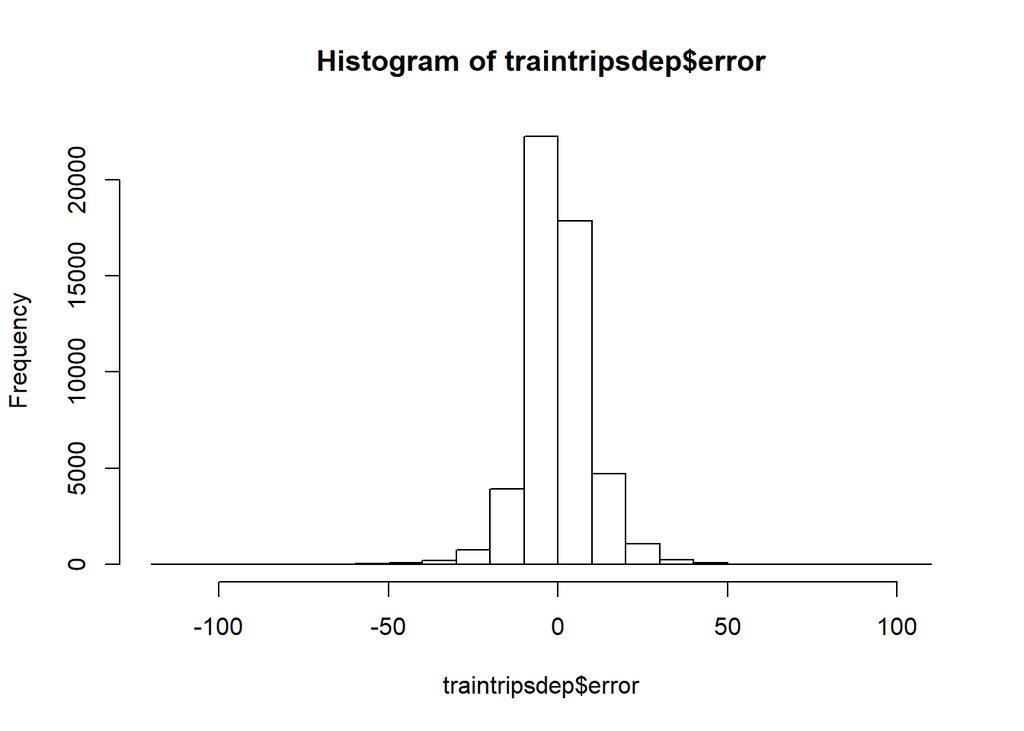

```r
# Check residual plots
hist(traintripsdep$error)
```

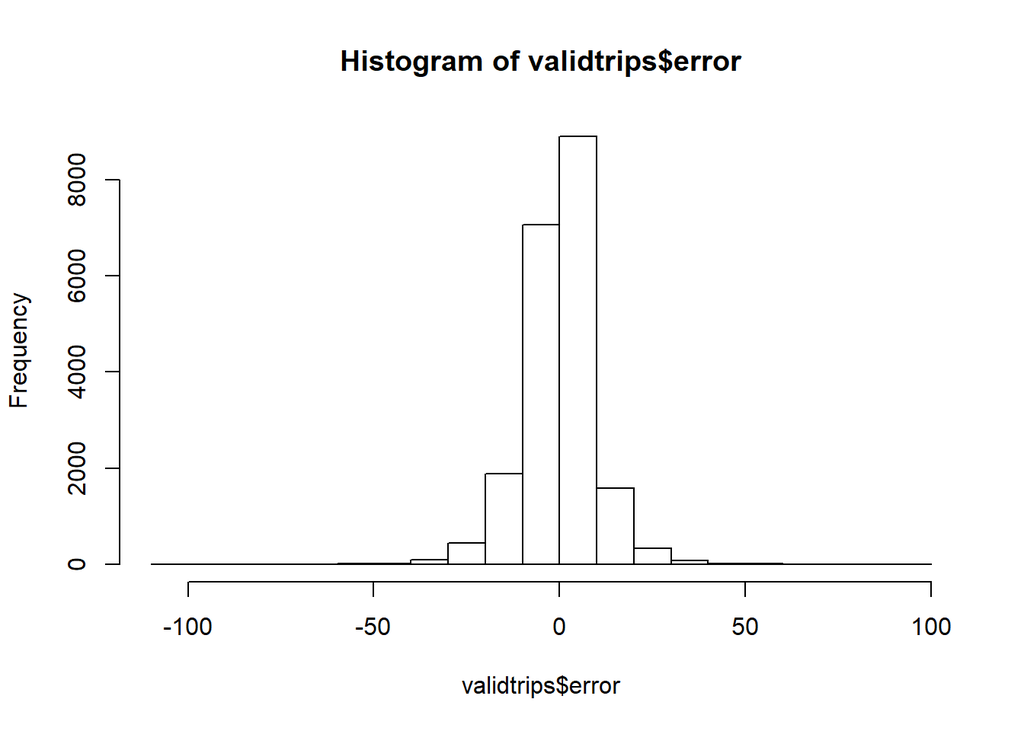

```r
hist(validtrips$error)
```

In both cases the histogram is centered at zero. Espicially with Test data. This is a good test. Follows nornal distribution which is a good measure of model performance.

#### Corelation

```r
# Correlation
a<-cor(traintripsdep$DepDelay,
       traintripsdep$pred.DepDelay )
b<-cor(validtrips$DepDelay,
       validtrips$predict.DepDelay )
a
```

```
## [1] 0.9743868
```

```r
b
```

```
## [1] 0.9722281
```

```r
a*a
```

```
## [1] 0.9494296
```

```r
b*b
```

```
## [1] 0.9452275
```

#### Corelation between actul and predicted is very high satisfying the accuracy of the model.

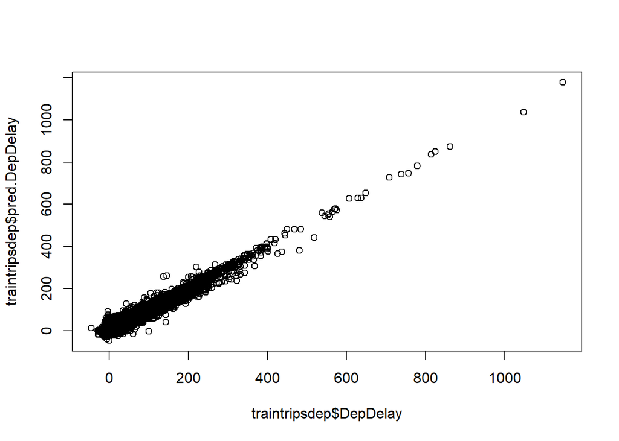

```r
plot(traintripsdep$DepDelay,
     traintripsdep$pred.DepDelay )
```

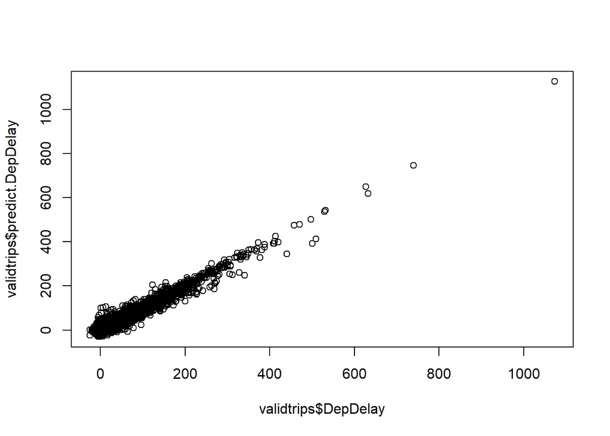

```r
plot(validtrips$DepDelay,
     validtrips$predict.DepDelay )
```

If we look at the Actual vs Predicted it almost follows stright line over diaognal.

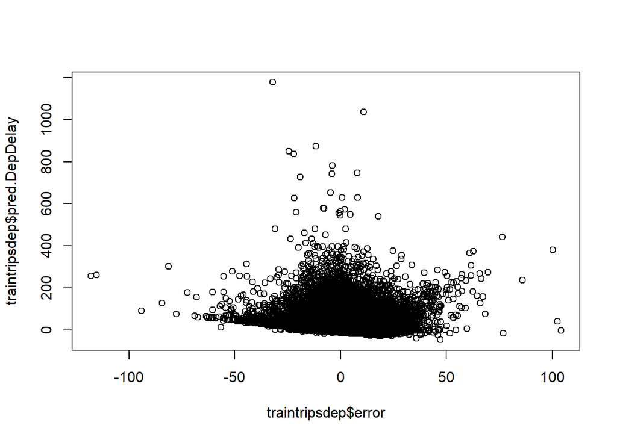

```r
plot(traintripsdep$error,
     traintripsdep$pred.DepDelay )
```

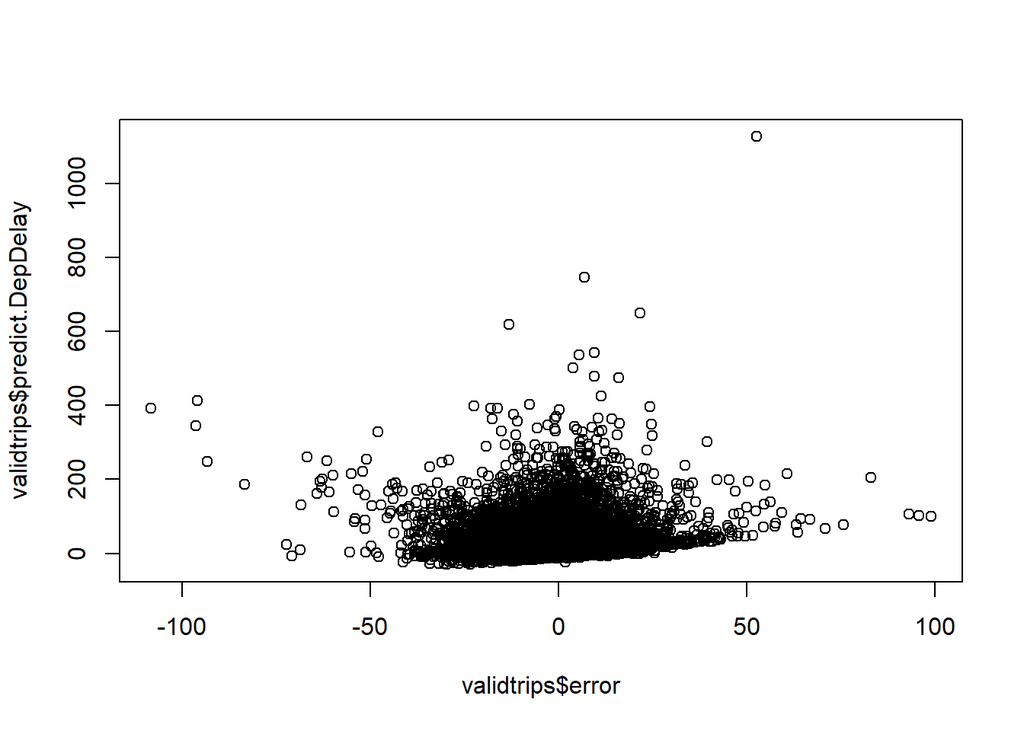

```r
plot(validtrips$error,
     validtrips$predict.DepDelay )
```

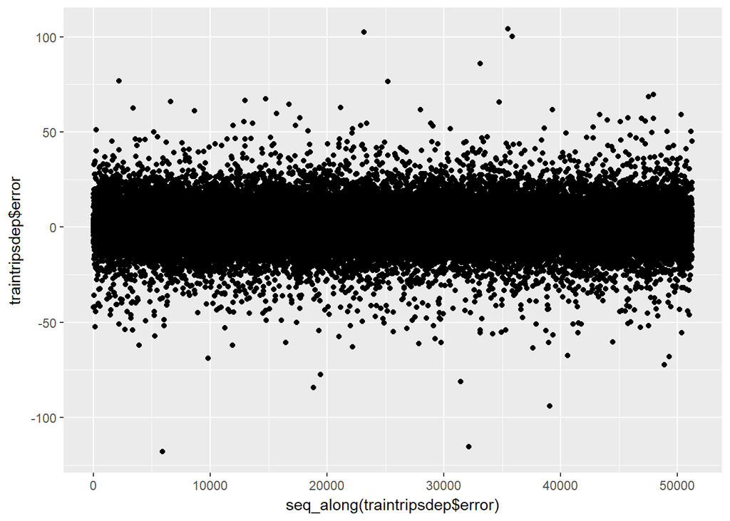

```r
qplot(y=traintripsdep$error)
```

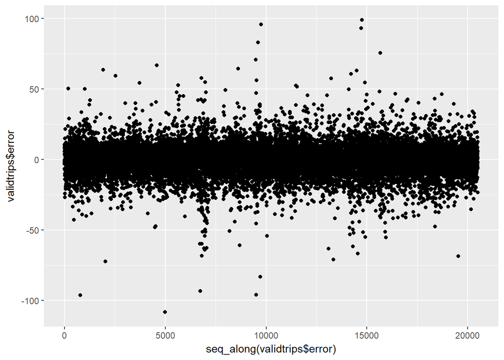

```r
qplot(y=validtrips$error)
```

There are very few outliers which is good as well.

Though we have tested each and every independent variable and max combinations before choosing final model. We can use alternate methods to choose variables. One of such methods is AIC. This takes combinations of variables and computes statistics. We have run STEP AIC and even with the first model seems to be best. Not showing STEPAIC here to save some real estate. In the actual code file we hae it.

#### Finally we can see that out first model is better.

#### Even if we get better model by tweeking the variables. It may not do well on completely new data.

#### Let’s verify both the models on test data set and conclude at the end.

### Now it’s time to predict ArrDelay as well. We can use DespDelay as well for predicting Arrival Delay.

Here, we can assume that DepDelay information is available and predict!. There is strong co-relation between two. This will be a very good predictor. Also, later we will make DepDelay not available and predict.

```r
traintripsArr <- traintrips
#traintripsArr <- traintrips[, !grepl("DepDelay" , names(traintrips))]  # Removing Arrvilal related variables.

lm.arr.fit1 <- stats::lm(ArrDelay ~ . , data=traintripsArr)
summary(lm.arr.fit1)
```

```
##
## Call:
## stats::lm(formula = ArrDelay ~ ., data = traintripsArr)
##
## Residuals:
##     Min      1Q  Median      3Q     Max
## -50.843  -3.656   0.637   4.318  78.772
##
## Coefficients: (14 not defined because of singularities)
##                              Estimate Std. Error t value Pr(>|t|)
## (Intercept)                 1.500e+01  1.185e+00  12.654  < 2e-16 ***
## `as.factor(Month)2`         2.066e-01  1.648e-01   1.253 0.210071
## `as.factor(Month)3`        -6.935e-02  1.593e-01  -0.435 0.663286
## `as.factor(Month)4`        -1.186e-01  1.626e-01  -0.729 0.465729
## `as.factor(Month)5`        -3.949e-01  1.612e-01  -2.450 0.014281 *
## `as.factor(Month)6`         5.546e-01  1.589e-01   3.490 0.000484 ***
## `as.factor(Month)7`        -4.322e-02  1.588e-01  -0.272 0.785560
## `as.factor(Month)8`        -1.758e-01  1.598e-01  -1.100 0.271318
## `as.factor(Month)9`        -1.552e+00  1.662e-01  -9.343  < 2e-16 ***
## `as.factor(Month)10`       -7.853e-01  1.640e-01  -4.787 1.69e-06 ***
## `as.factor(Month)11`       -1.383e+00  1.633e-01  -8.470  < 2e-16 ***
## `as.factor(Month)12`        9.067e-02  1.600e-01   0.567 0.570953
## `as.factor(DayOfWeek)2`    -2.687e-01  1.202e-01  -2.236 0.025386 *
## `as.factor(DayOfWeek)3`    -2.923e-02  1.197e-01  -0.244 0.807040
## `as.factor(DayOfWeek)4`     5.451e-01  1.190e-01   4.581 4.64e-06 ***
## `as.factor(DayOfWeek)5`     5.520e-01  1.185e-01   4.659 3.19e-06 ***
## `as.factor(DayOfWeek)6`    -7.727e-01  1.258e-01  -6.141 8.24e-10 ***
## `as.factor(DayOfWeek)7`    -1.205e-01  1.212e-01  -0.994 0.320240
## UniqueCarrierAQ            -9.034e-01  6.136e-01  -1.472 0.140941
## UniqueCarrierAS            -6.928e-01  3.339e-01  -2.075 0.038035 *
## UniqueCarrierB6            -2.280e+00  2.595e-01  -8.784  < 2e-16 ***
## UniqueCarrierCO            -2.126e+00  2.195e-01  -9.689  < 2e-16 ***
## UniqueCarrierDL            -6.049e-01  2.291e-01  -2.641 0.008277 **
## UniqueCarrierEV            -3.018e-01  2.772e-01  -1.089 0.276194
## UniqueCarrierF9             1.050e+00  3.355e-01   3.130 0.001746 **
## UniqueCarrierFL             7.988e-01  2.511e-01   3.181 0.001466 **
## UniqueCarrierHA             4.503e-02  5.683e-01   0.079 0.936846
## UniqueCarrierMQ             1.494e-01  1.971e-01   0.758 0.448436
## UniqueCarrierNW             1.381e+00  2.642e-01   5.228 1.72e-07 ***
## UniqueCarrierOH            -3.661e-01  2.766e-01  -1.324 0.185670
```

[output cut: 169 more lines]

```
## `as.factor(Originstate)WI` -1.031e+00  6.858e-01  -1.503 0.132911
## `as.factor(Originstate)WV` -2.151e-01  1.530e+00  -0.141 0.888217
## `as.factor(Originstate)WY` -1.017e+00  1.023e+00  -0.995 0.319825
## TaxiOut                     4.109e+00  5.035e-02  81.620  < 2e-16 ***
## CarrierDelay                1.952e+01  9.524e-02 204.979  < 2e-16 ***
## WeatherDelay                8.397e+00  4.948e-02 169.709  < 2e-16 ***
## NASDelay                    1.663e+01  6.803e-02 244.467  < 2e-16 ***
## LateAircraftDelay           1.997e+01  9.719e-02 205.479  < 2e-16 ***
## DepDelay                    2.725e-01  3.314e-03  82.236  < 2e-16 ***
## ---
## Signif. codes:  0 '***' 0.001 '**' 0.01 '*' 0.05 '.' 0.1 ' ' 1
##
## Residual standard error: 7.33 on 51046 degrees of freedom
## Multiple R-squared:  0.9752, Adjusted R-squared:  0.9751
## F-statistic: 1.042e+04 on 193 and 51046 DF,  p-value: < 2.2e-16
```

#### R-Squared: 97 and Residual error: 7

### Plots For Arrival Delay

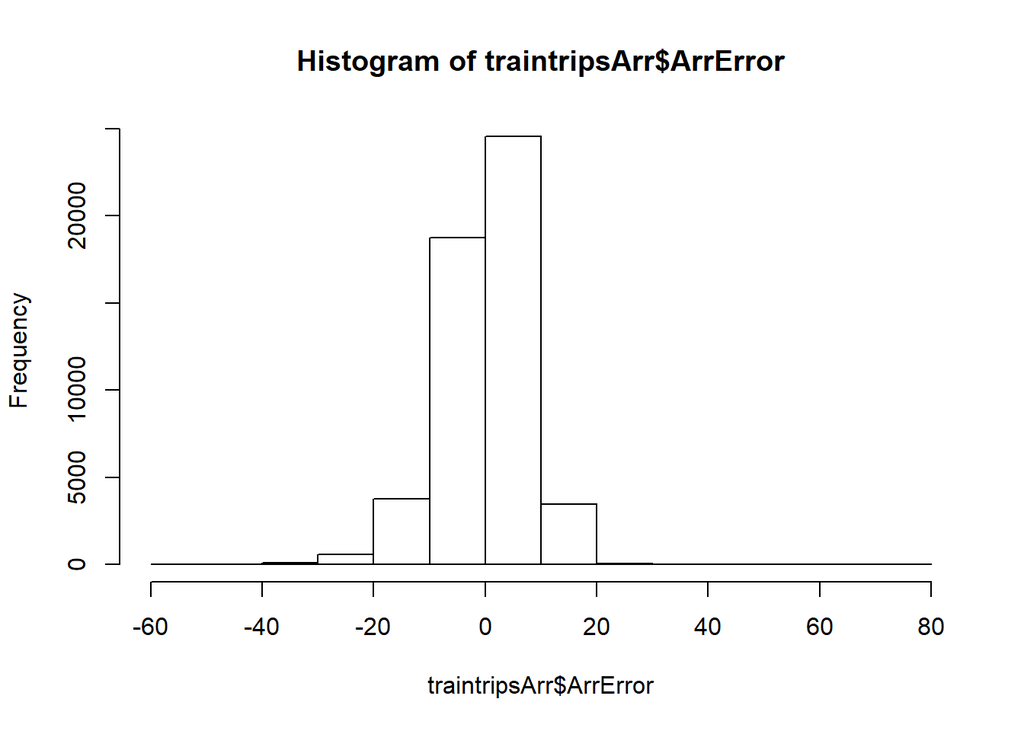

```r
# Check residual plots
hist(traintripsArr$ArrError)
```

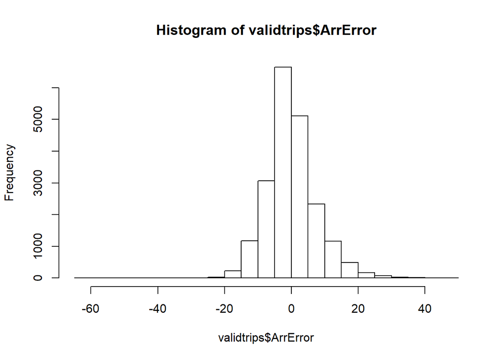

```r
hist(validtrips$ArrError)
```

In both cases the histogram is centered at zero. Espicially with Test data. This is a good test. Follows nornal distribution which is a good measure of model performance.

#### Correlation

```r
a<-cor(traintripsArr$ArrDelay,
       traintripsArr$pred.ArrDelay )
b<-cor(validtrips$ArrDelay,
       validtrips$predict.ArrDelay )
a
```

```
## [1] 0.9875435
```

```r
b
```

```
## [1] 0.9870084
```

```r
a*a
```

```
## [1] 0.9752422
```

```r
b*b
```

```
## [1] 0.9741855
```

co-relation between actul and predicted is very high satisfying the accuracy of the model.

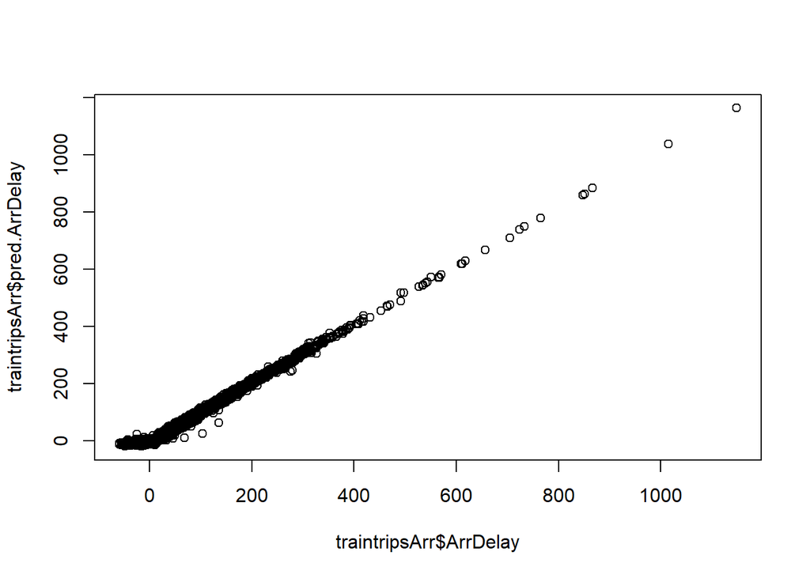

```r
plot(traintripsArr$ArrDelay,
     traintripsArr$pred.ArrDelay )
```

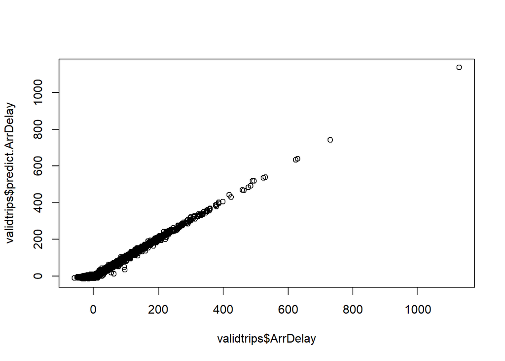

```r
plot(validtrips$ArrDelay,
     validtrips$predict.ArrDelay )
```

If we look at the Actual vs Predicted it almost follows stright line over diaognal.

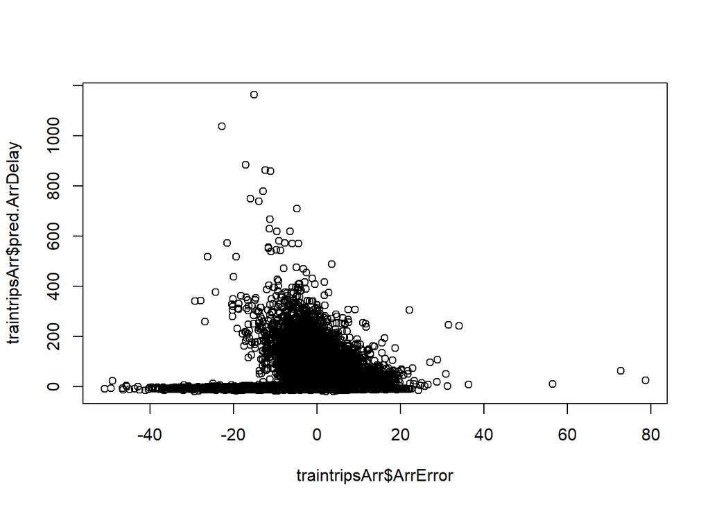

```r
plot(traintripsArr$ArrError,
     traintripsArr$pred.ArrDelay )
```

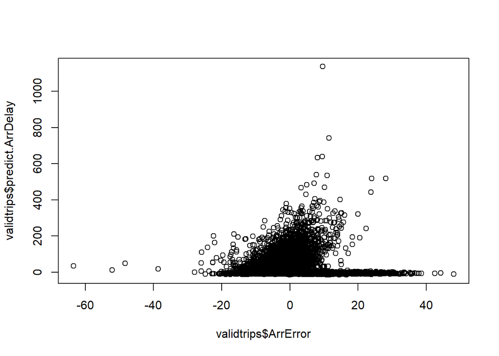

```r
plot(validtrips$ArrError,
     validtrips$predict.ArrDelay )
```

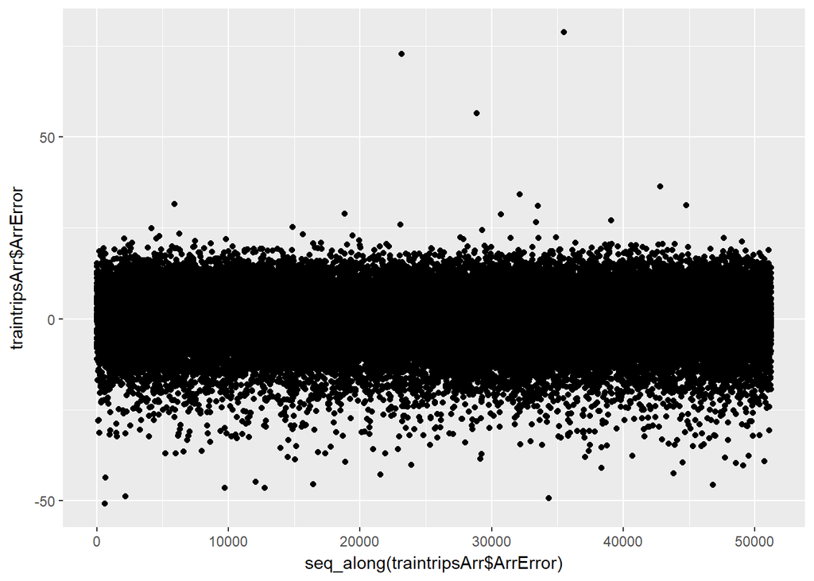

```r
qplot(y=traintripsArr$ArrError)
```

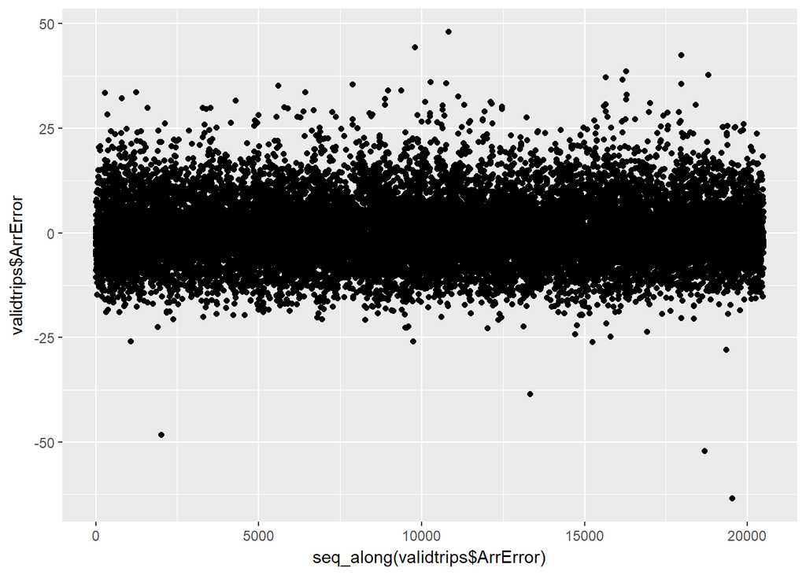

```r
qplot(y=validtrips$ArrError)
```

Follows normal distributuon. #### Model performance is good and accuracy is good as well.

#### We can try removing DepDelay (independent variable) and try and predict the ArrDelay.

Not showing all the plotsto sae some realestate. But in actual code file, we have it.

[output not shown]

[output cut: 86 more lines]

```
## [1] 209
```

```
##
## Call:
## stats::lm(formula = ArrDelay ~ ., data = traintripsArr)
##
## Residuals:
##     Min      1Q  Median      3Q     Max
## -51.141  -3.620   1.086   3.880 107.159
##
## Coefficients: (14 not defined because of singularities)
##                              Estimate Std. Error t value Pr(>|t|)
## (Intercept)                 19.726105   1.259747  15.659  < 2e-16 ***
## `as.factor(Month)2`          0.305298   0.175393   1.741 0.081751 .
## `as.factor(Month)3`         -0.002561   0.169508  -0.015 0.987947
## `as.factor(Month)4`         -0.012316   0.173008  -0.071 0.943251
## `as.factor(Month)5`         -0.386404   0.171521  -2.253 0.024275 *
## `as.factor(Month)6`          0.753057   0.169112   4.453 8.49e-06 ***
## `as.factor(Month)7`          0.270340   0.168982   1.600 0.109646
## `as.factor(Month)8`          0.202276   0.170008   1.190 0.234131
## `as.factor(Month)9`         -1.622392   0.176818  -9.175  < 2e-16 ***
## `as.factor(Month)10`        -0.801629   0.174554  -4.592 4.39e-06 ***
## `as.factor(Month)11`        -1.284378   0.173747  -7.392 1.47e-13 ***
## `as.factor(Month)12`         0.320400   0.170247   1.882 0.059846 .
## `as.factor(DayOfWeek)2`     -0.508444   0.127866  -3.976 7.01e-05 ***
## `as.factor(DayOfWeek)3`     -0.135152   0.127339  -1.061 0.288532
## `as.factor(DayOfWeek)4`      0.490917   0.126629   3.877 0.000106 ***
## `as.factor(DayOfWeek)5`      0.530378   0.126097   4.206 2.60e-05 ***
## `as.factor(DayOfWeek)6`     -0.902117   0.133887  -6.738 1.62e-11 ***
## `as.factor(DayOfWeek)7`     -0.180355   0.128955  -1.399 0.161942
## UniqueCarrierAQ             -1.175233   0.652943  -1.800 0.071882 .
## UniqueCarrierAS             -0.795532   0.355365  -2.239 0.025184 *
## UniqueCarrierB6             -1.854493   0.276144  -6.716 1.89e-11 ***
## UniqueCarrierCO             -1.278128   0.233289  -5.479 4.30e-08 ***
## UniqueCarrierDL             -0.379183   0.243745  -1.556 0.119797
## UniqueCarrierEV              0.098643   0.294941   0.334 0.738041
## UniqueCarrierF9              1.306389   0.357053   3.659 0.000254 ***
## UniqueCarrierFL             -0.019249   0.266968  -0.072 0.942519
## UniqueCarrierHA             -0.122986   0.604735  -0.203 0.838846
## UniqueCarrierMQ              0.004951   0.209768   0.024 0.981172
## UniqueCarrierNW              1.181881   0.281126   4.204 2.63e-05 ***
## UniqueCarrierOH             -0.084631   0.294325  -0.288 0.773699
```

[output cut: 168 more lines]

```
## `as.factor(Originstate)WA`   0.040307   0.614298   0.066 0.947685
## `as.factor(Originstate)WI`  -1.137931   0.729791  -1.559 0.118942
## `as.factor(Originstate)WV`  -1.947528   1.628291  -1.196 0.231680
## `as.factor(Originstate)WY`  -0.857067   1.088117  -0.788 0.430899
## TaxiOut                      1.712525   0.043688  39.199  < 2e-16 ***
## CarrierDelay                26.846078   0.035961 746.532  < 2e-16 ***
## WeatherDelay                11.425596   0.035167 324.894  < 2e-16 ***
## NASDelay                    21.252739   0.040829 520.525  < 2e-16 ***
## LateAircraftDelay           27.482554   0.035349 777.470  < 2e-16 ***
## ---
## Signif. codes:  0 '***' 0.001 '**' 0.01 '*' 0.05 '.' 0.1 ' ' 1
##
## Residual standard error: 7.801 on 51047 degrees of freedom
## Multiple R-squared:  0.972,  Adjusted R-squared:  0.9719
## F-statistic:  9217 on 192 and 51047 DF,  p-value: < 2.2e-16
```

It may predict well on Validation data set.

#### Even here model performance is good and accuracy is good as well.

#### We can use eaither of the models. If it is for predicting much earlier say week before the flight, then we don’t have DepDelay info so we can use second on. But if you are using for realtime flight delay prediction than we can use first one.

#### Finally, we need to apply this model to test data set to see the results.

### And once this is ready, we need to use the final model in function which accepts these input variables as parameters and predicts the delay.

### For Departure.

```r
#  Predict values on test set
testtrips$predict.DepDelay <- predict(lm.dep.fit1,
                                       newdata=testtrips)
```

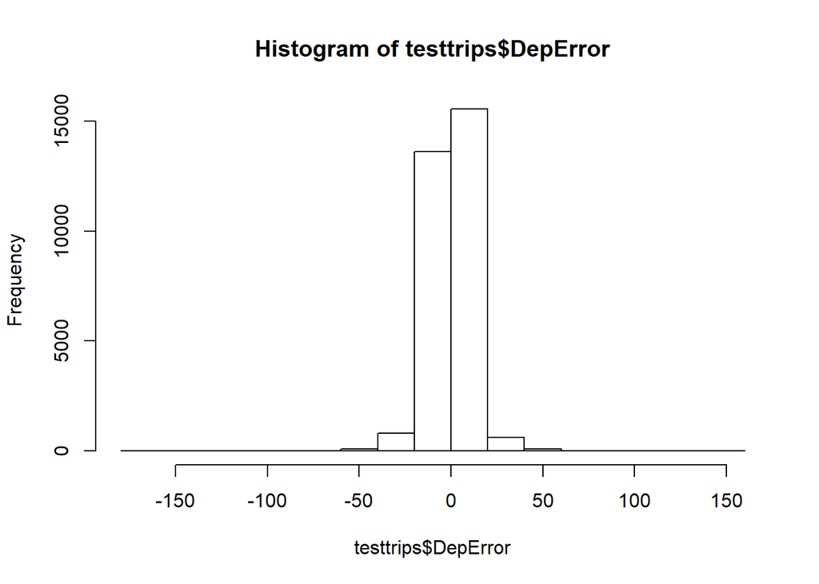

```r
testtrips$DepError <-
  testtrips$predict.DepDelay - testtrips$DepDelay


hist(testtrips$DepError)
```

#### In both cases the histogram is centered at zero on test data which is good. #### Follows nornal distribution which is a good measure of model performance.

#### The accuracy seems to be better then validation data set for departure.

### For Arrival.

```r
#  Predict values on test set
testtrips$predict.ArrDelay <- predict(lm.arr.fit2,
                                       newdata=testtrips)
```

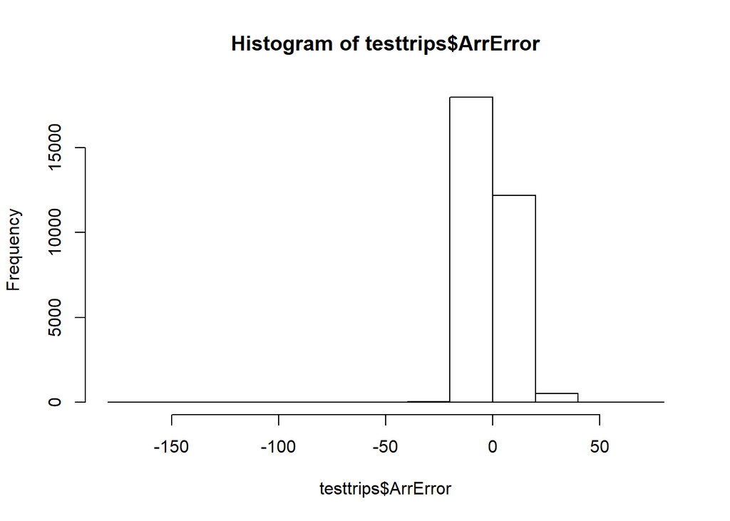

```r
testtrips$ArrError <-
  testtrips$predict.ArrDelay - testtrips$ArrDelay

hist(testtrips$ArrError)
```

This is a good test. Follows nornal distribution which is a good measure of model performance.

#### Accuracy is good for test data set as well. Too many plots. Let’s stop here.

### So the model coosen for production are lm.dep.fita for Departure and lm.arr.fit2 for Arrival.

### Now let’s answer other questions.

## Can you detect cascading failures as delays in one airport create delays in others?

## Are there critical links in the system?

To detect cascading failures, have devided 24 hours into 4 buckets. i.e new variables DepTimeOfDay, ArrTimeOfDay 12am to 5:59 am as 0 (Night) 6am to 11:59 am as 1 (Morning) 12noon to 5:59pm (Afternoon) 6pm to 11:59pm (Evening)

This is to check if there is delay in previous bucket, will it have impact in next bucket in the Airport context. We could do it hourly, but for convinence have choosen this. We can try hourly as well.

Now let’s take e.g: Let’s Say. Delays (Both ArrDelay and DepDelay) in Origin at a given time can cause Delays in later time at Dependent Dest.

Let’s see what is Mean Delay(Arr, Dep) at Origin over DepTimeOfDay.

```r
tripsOrigin <- select (trips, Origin, Dest,  DepDelay, ArrDelay, DepTimeofday, ArrTimeofday )
tripsDest <- select (trips, Origin, Dest, DepDelay, ArrDelay, DepTimeofday, ArrTimeofday )

tripsOriginFD <- tripsOrigin %>%
  group_by(Origin, Dest, DepTimeofday , ArrTimeofday ) %>%
  summarise(md=mean(DepDelay), ma = mean(ArrDelay))

AirDestFD <- tripsOrigin %>%
  group_by( Dest, ArrTimeofday  ) %>%
  summarise(md1=mean(DepDelay), ma1 = mean(ArrDelay))

tripsOriginFD <- as.data.frame(tripsOriginFD)
AirDestFD <- as.data.frame(AirDestFD)
```

Joining the tables… Matching “Dest and ArrTime

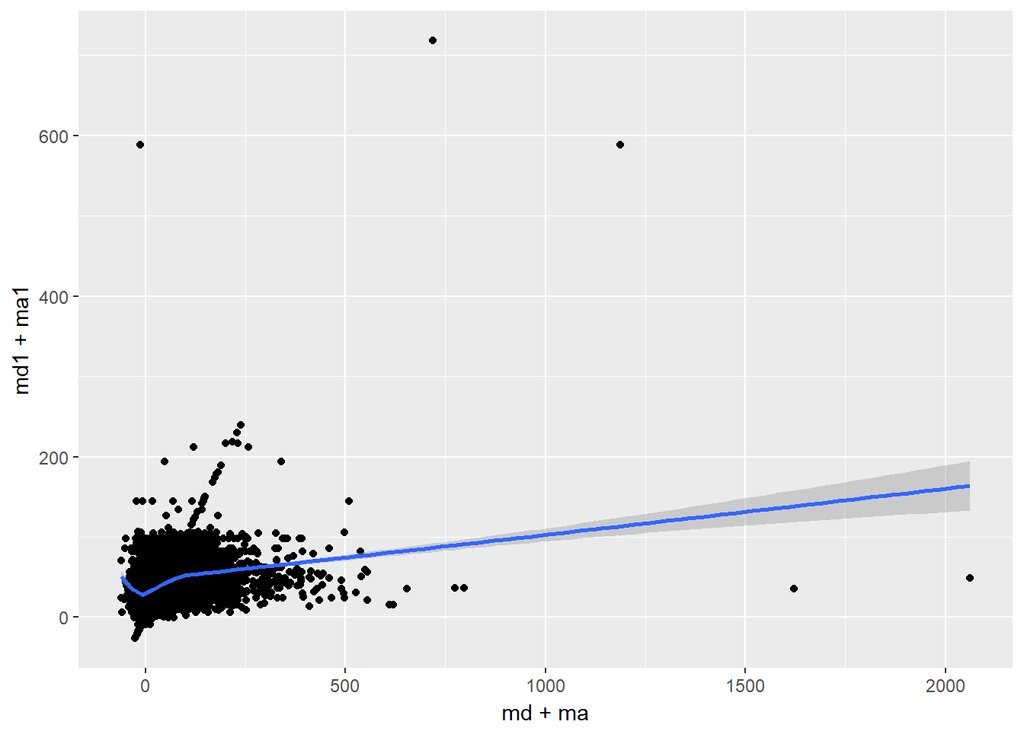

```r
AirportDep <- merge(x=tripsOriginFD, y=AirDestFD, by.x = c("Dest", "ArrTimeofday"), by.y= c("Dest", "ArrTimeofday"))


ggplot(AirportDep, aes(md+ma, md1+ma1)) + geom_point() + geom_smooth()
```

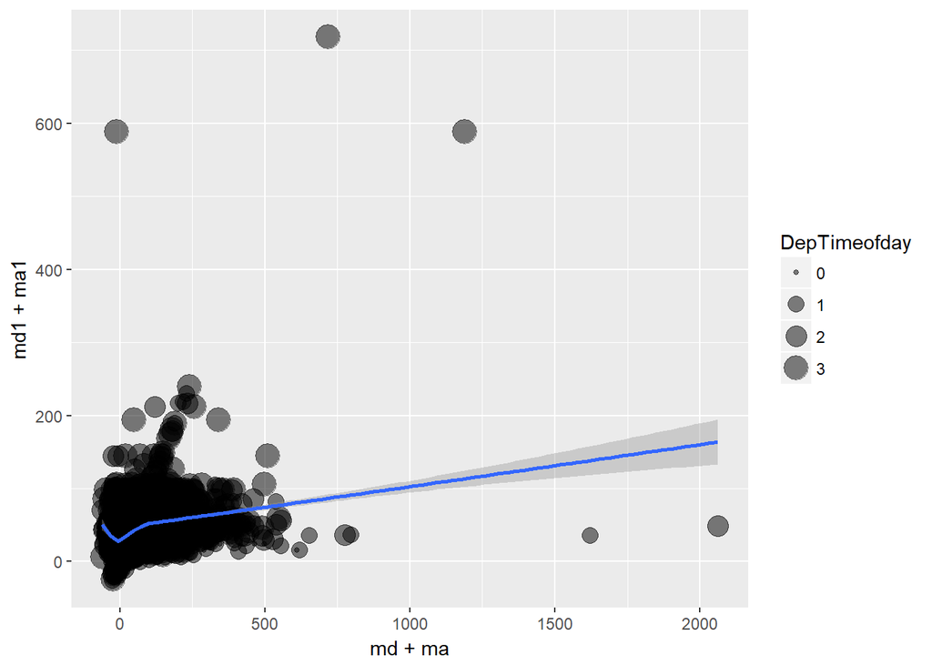

```r
ggplot(AirportDep, aes(md+ma, md1+ma1)) + geom_point(aes(size=DepTimeofday), alpha=1/2) + geom_smooth()
```

This doesn’t say anything.

We need to agreegate Based on Dest, ArrTime of day and find mean delay at Origin vs Dest and plot

```r
AirportDep1 <- AirportDep %>% group_by(Dest,ArrTimeofday) %>%
  summarize(mdo=mean(md), mao=mean(ma), mdd=mean(md1), mad=mean(ma1) )

head(AirportDep1,20)
```

```
## # A tibble: 20 x 6
## # Groups:   Dest [7]
##     Dest ArrTimeofday        mdo         mao       mdd        mad
##    <chr>        <dbl>      <dbl>       <dbl>     <dbl>      <dbl>
##  1   ABE            0 120.000000 119.0000000 120.00000 119.000000
##  2   ABE            1  12.212500   8.3500000  15.38889  11.388889
##  3   ABE            2  10.882639  12.0493056  11.54839  14.032258
##  4   ABE            3  43.219048  40.4242063  38.12500  35.166667
##  5   ABI            1  -3.250000 -10.5000000  -3.25000 -10.500000
##  6   ABI            2  25.777778  25.3888889  25.77778  25.388889
##  7   ABI            3  28.882353  32.2058824  31.00000  31.772727
##  8   ABQ            0  44.400000  40.4000000  44.40000  40.400000
##  9   ABQ            1   3.717516  -0.1011489   4.91358   1.537037
## 10   ABQ            2  12.220792   8.7111117  14.32061  12.053435
## 11   ABQ            3  19.144955  16.4355726  22.32500  21.500000
## 12   ABY            1   3.500000  20.0000000   3.50000  20.000000
## 13   ABY            2  15.250000  15.5000000  15.25000  15.500000
## 14   ABY            3  78.500000  66.1666667  78.50000  66.166667
## 15   ACK            2  -5.000000  -8.0000000  -5.00000  -8.000000
## 16   ACK            3  18.333333  19.8888889  14.14286  14.428571
## 17   ACT            1   8.625000   6.0000000   8.62500   6.000000
## 18   ACT            2  15.869565  13.8695652  15.86957  13.869565
## 19   ACT            3  -3.750000  -7.2500000  -3.75000  -7.250000
## 20   ACV            0  46.000000  41.0000000  46.00000  41.000000
```

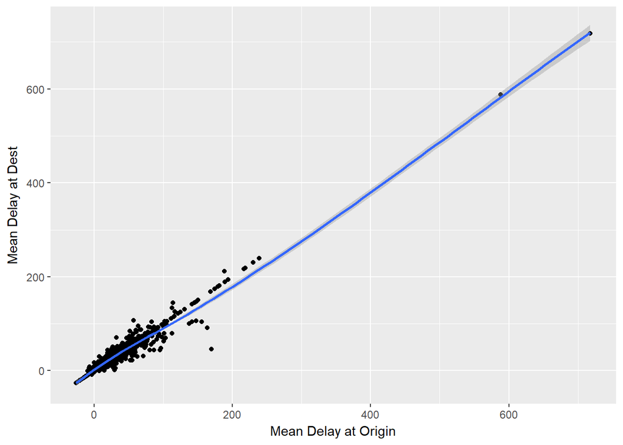

```r
ggplot(AirportDep1, aes(mdo+mao, mdd+mad)) + geom_point() + geom_smooth() + xlab("Mean Delay at Origin") + ylab("Mean Delay at Dest")
```

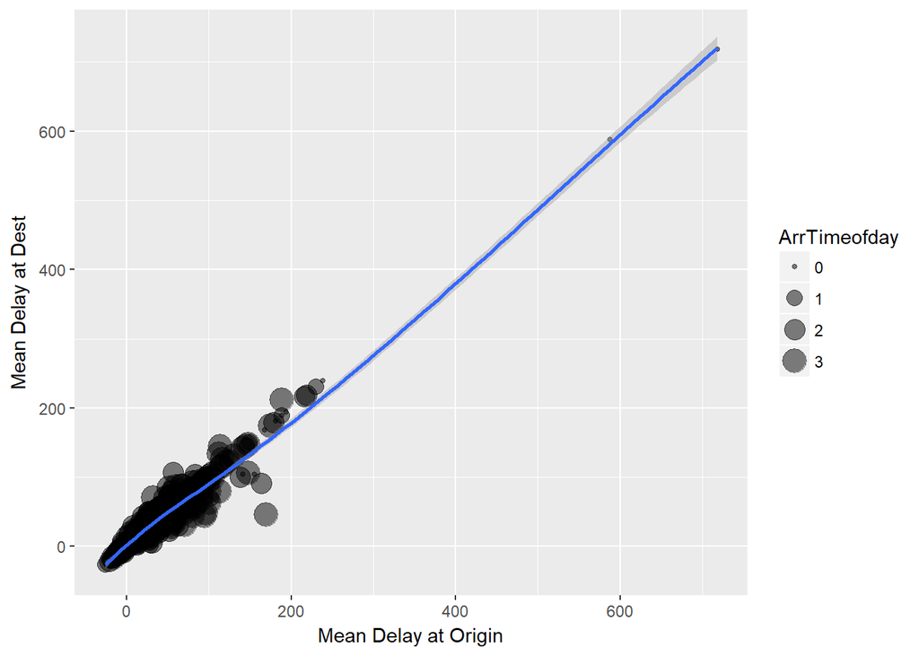

```r
ggplot(AirportDep1, aes(mdo+mao, mdd+mad)) + geom_point(aes(size=ArrTimeofday), alpha=1/2) + geom_smooth() + xlab("Mean Delay at Origin") + ylab("Mean Delay at Dest")
```

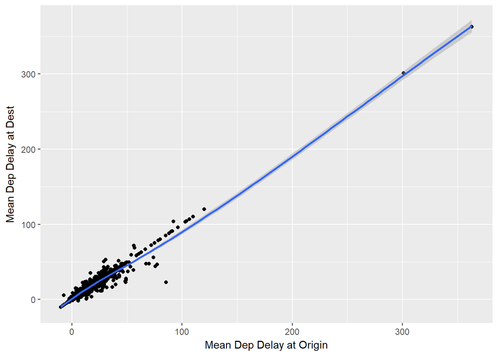

```r
ggplot(AirportDep1, aes(mdo, mdd)) + geom_point() + geom_smooth() + xlab("Mean Dep Delay at Origin") + ylab("Mean Dep Delay at Dest")
```

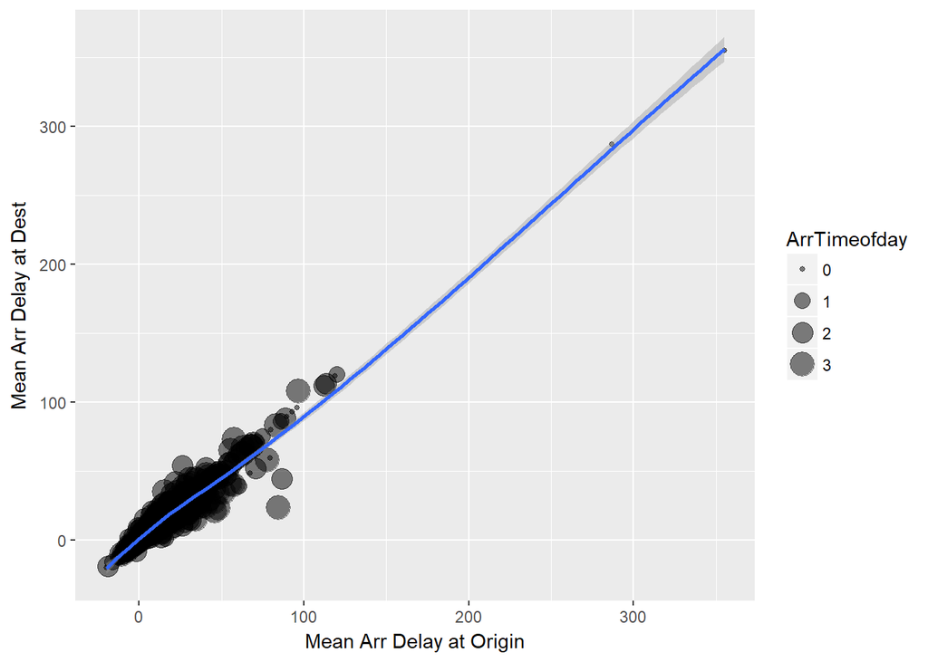

```r
ggplot(AirportDep1, aes(mao, mad)) + geom_point(aes(size=ArrTimeofday), alpha=1/2) + geom_smooth() + xlab("Mean Arr Delay at Origin") + ylab("Mean Arr Delay at Dest")
```

Clearly, there is leanier relationship between delays in one airport cascading to downstream airports. Have ploted the same above.

### Critical link is: For a given airport at a given TimeOfDay, match Dest Airport from the upstream(Ogigin) and Arrival times.

Infact, we can very well use this as a feature in predicting ArrTime and DepTime. Accuracy will significantly improve. I am not going there, given we have limited time now.

## Can Weather Predict Flight delayes ?

Certainly, weather has influence on ArrDelay and DepDelay as we have seen in Exploratory Data Analysis. However, if we could download weather data, we could have further expanded on this. The site is not up for few days. For the same model, WeatherDelay parameter should be passed from what we get from site provided.

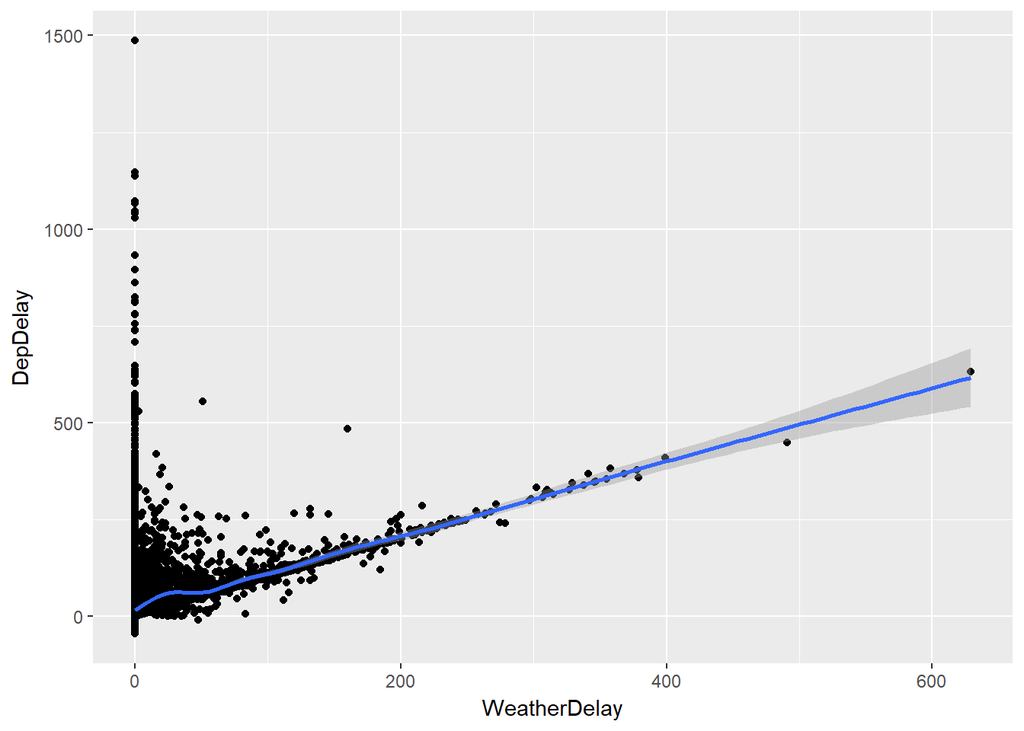

```r
# Reproducing same graphs again.
ggplot(tripsplaneairports, aes(WeatherDelay, DepDelay)) + geom_point() + geom_smooth() + scale_size_area(max_size = 2)
```

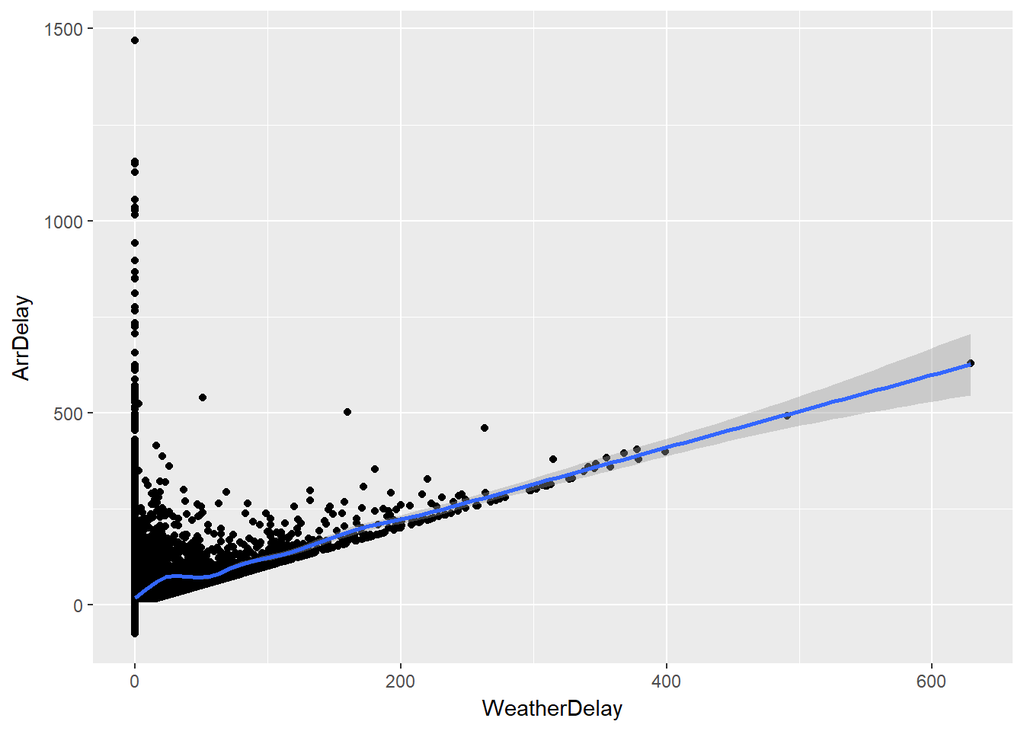

```r
ggplot(tripsplaneairports, aes(WeatherDelay, ArrDelay)) + geom_point() + geom_smooth() + scale_size_area(max_size = 2)
```

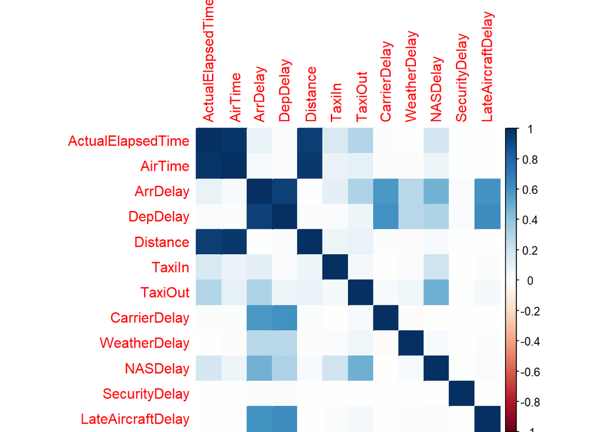

```r
# Let's plot the co-relation matix one more time.
corrplot(tripscorr, method="color")
```

## Running same analysis on BigData/Spark

#### Connecting to Spark Local server

```r
sc <- spark_connect(master = "local")
```

```
## * Using Spark: 2.1.0
```

## Exploratory Data Analysis

### Carrier on-time performance

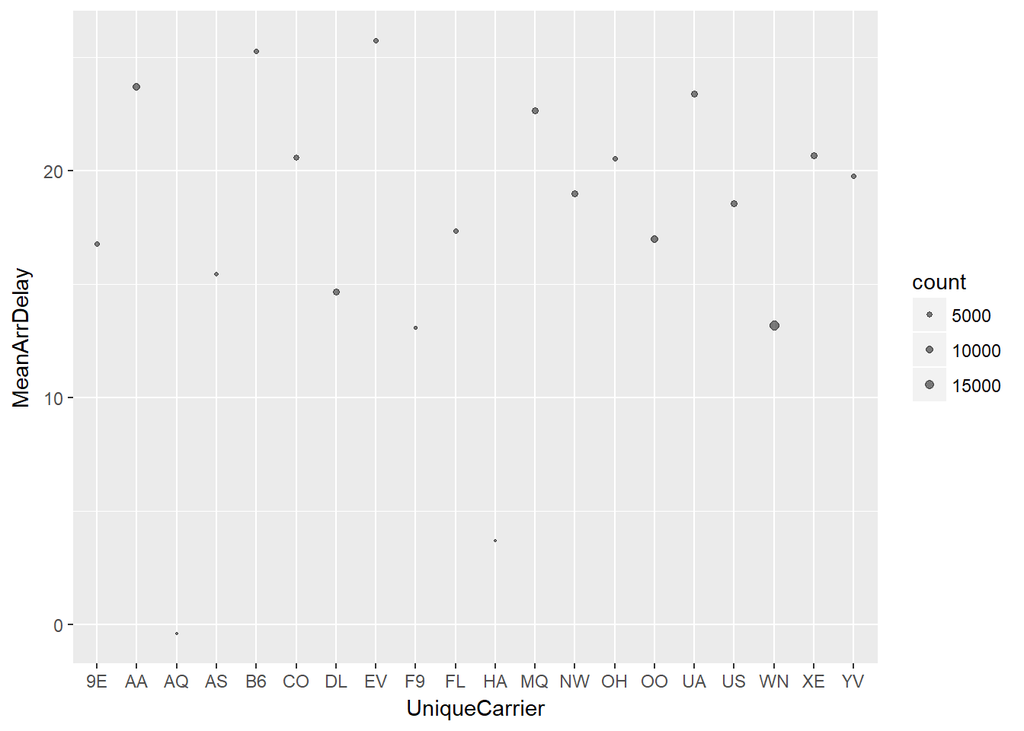

```r
tripsdelayCarrier <- trips_tbl2 %>%
  group_by(UniqueCarrier) %>%
  summarise(count=n(), MeanArrDelay=mean(ArrDelay), MeanDepdelay=mean(DepDelay)) %>%
  filter (count > 20 ) %>%
  collect
#Plot the delay

ggplot(tripsdelayCarrier, aes(UniqueCarrier, MeanArrDelay)) + geom_point(aes(size=count), alpha=1/2) + scale_size_area(max_size = 2)
```

### Delays in each month

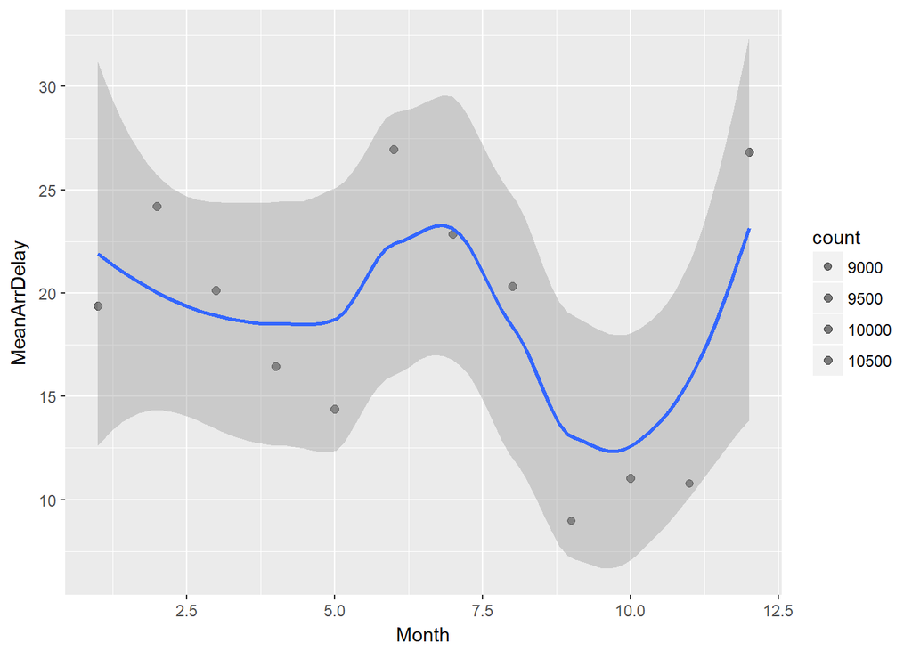

```r
tripsdelayMonth <- trips_tbl2 %>%
  group_by(Month) %>%
  summarise(count=n(), MeanArrDelay=mean(ArrDelay), MeanDepdelay=mean(DepDelay)) %>%
  filter (count > 20 ) %>%
  collect
#Plot the delay

ggplot(tripsdelayMonth, aes(Month, MeanArrDelay)) + geom_point(aes(size=count), alpha=1/2) + geom_smooth() + scale_size_area(max_size = 2)
```

### Linear regression with Spark ML Lib (Just an example)

```
## * No rows dropped by 'na.omit' call
```

Summarize the linear model

```r
summary(mlfit1)
```

```
## Call: ml_linear_regression(., DepDelay ~ WeatherDelay + Month)
##
## Deviance Residuals::
##      Min       1Q   Median       3Q      Max
##  -73.389  -20.381  -16.113    3.351 1120.084
##
## Coefficients:
##               Estimate Std. Error t value  Pr(>|t|)
## (Intercept)  18.791667   0.310249 60.5696 < 2.2e-16 ***
## WeatherDelay  0.984910   0.011701 84.1729 < 2.2e-16 ***
## Month        -0.267882   0.042433 -6.3131 2.748e-10 ***
## ---
## Signif. codes:  0 '***' 0.001 '**' 0.01 '*' 0.05 '.' 0.1 ' ' 1
##
## R-Squared: 0.07861
## Root Mean Squared Error: 42.22
```

### Let’s predict on validation data set.

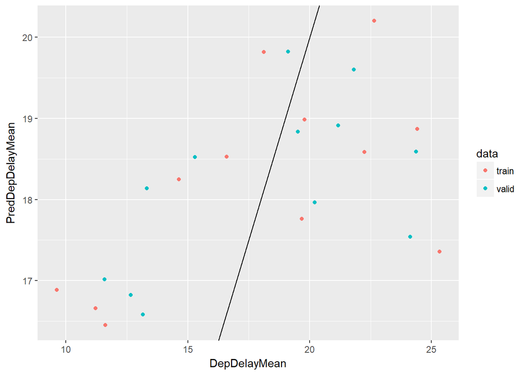

```r
model_pred <- lapply(model_partition, function(x) {
  sdf_predict(mlfit1, x) %>%
    collect()
})

# Since there are large number of points, before plotting let's summarize
sum1 <- rbind(
  data.frame(data = 'train', model_pred$tripstrain),
  data.frame(data = 'valid', model_pred$tripsvalid),
  make.row.names = FALSE
)

predsum <- sum1 %>%
           group_by(Month, data) %>%
           summarize( DepDelayMean = mean(DepDelay), PredDepDelayMean = mean(prediction) ) %>%
           collect()


ggplot(predsum, aes(DepDelayMean, PredDepDelayMean, color=data)) + geom_point() + geom_abline()
```

From results it’s clear that we don’t necessirly have choosen all the features. We can continue same steps we did on R on spark environment as well and surely we will have similar results. Leaving this here given my Spark session terminates frequently and RStudio behaving not as expected.

## Conclusion:

It was a great case study both techncally and also to understand different domain.

### Future imporovements and suggestios

1. We have taken only sample data hence peformance possibly be enhanced by running same analysis Spark. But steps wouldn’t change much.
2. We have had 29 + another 10 + varlables to work with. So tried testing each and every variable and it’s significance. We could try Principal Component Analysis and then use the principal comonents to predict outcome.
3. We can also pre-define what is delay, i.e more then certain minutes as delay (e.g: more then 10min as delay) and turn this into Classification problem. And once classified then start predicting the delay minutes using linear regression. To check if there is alternates that can add value.
4. Airport Cascading delays, precalculated transformed features can be used in model prediction(not used here due to time constranit though answered questions). This will be a very good predictor.
5. Some of the delays such as CarrierDelay etc.. are realtime hence while using this model in production we need to eaither get mean values for a given criteria from historical data and use in prediction or build different model.
6. Before using this model in production, there is some work to be done listed above. And ofcourse, we need to modularize the code and create functions for all repetative tasks. Also, create functions to answer questions.